# Success-rate targeting in the LEVANTE CATs

How hard should a task be, what does an easier target cost, and where are we now?

Author

Vlad Chituc

Published

August 23, 2026

**WarningPreliminary & unvetted**

Analyses were built with AI assistance and have not been reviewed by anyone else. Everything traces to the numbered scripts in `scripts/` at the repository root and their results JSON; the analysis-by-analysis record of the verification behind each claim is `notes/audit-battery.qmd`. Working draft.

# Topline

**ImportantWhat to take away**

**One task is broken, and we can say exactly how and why.** Pattern Matching’s CAT realizes **39% correct against a 68% optimum** — the only task in the battery serving items *harder* than the child, by a median 2.4 logits. The cause is the item bank, not the algorithm: median item difficulty is +1.97 against a median child ability of −0.68, and only 12 of 151 items fall below −1. It retains **36% of the information it could** — a 31-item test measuring like an 11-item one. Ages 5–7 sit at 31–33% correct, barely above the 25% you get by guessing. The CAT’s own trace shows the mechanism: its running ability estimate is *flat* near −2.3 logits while the difficulty it serves climbs from +0.7 to +2.1 — the algorithm knows where the child is and has nothing to serve there (Section 6.1).

**The rest of the battery is largely fine.** Four of seven CATs sit within a few points of their own optimum. This is not a systemic problem with adaptive testing or with how LEVANTE runs it — it is one bank that was never built out at the easy end (Section 6).

**Making a task easier is close to free near the optimum, and expensive past it.** On a 4-choice task at fixed length, moving from 68% to 75% costs 4% of the information — a reliability of .90 becomes .896, which nobody would notice. Moving to 85% costs 27% and takes .90 down to .868. The decision point is the high seventies, not 90% (Section 7).

**Harder trials cause more rapid guessing, within child — the pilot data can now say so.** Holding the child fixed (run fixed effects) and controlling within-run position, a trial’s expected accuracy moving from 1 to 0 adds **1.5 percentage points** of rapid-guess probability on a ~1.5% base (P < .001). The effect survives a threshold that cannot scale with item difficulty (−0.5pp, the conservative bound) and two artifact checks; it is negative in **24 of 26 task × variant × age cells** (10 after correction), in both age bands, and null exactly where it should be — Word Reading and Hearts & Flowers, the two tasks already serving at or below the child (Section 8).

**Children who fall behind disengage, and failure itself does the damage.** The preceding-streak effect on rapid guessing survives within-run position control with only **5% attenuation** (+1.4pp at three or more consecutive errors). And holding the *difficulty* of the previous three trials fixed — which makes their outcomes as-good-as-random — each additional failure among them adds **+0.3 / +1.1 / +2.0pp** of rapid-guess risk at one / two / three wrong. Along a streak, wrong answers speed up three times faster than correct ones, so the engaged-error signature collapses from **0.28 to 0.02** within-child SD (Section 12).

**A rescue rule would cost almost nothing, but it cannot fix much either.** Handing a child one easy item after four consecutive errors costs under 0.2% of the task’s information battery-wide and cuts rapid guessing about 5% — 19% on Pattern Matching. Resetting after *every* error, an absurd design, would cut it only 43%, because most rapid guessing never follows a streak. The rule is a nearly-free UX patch whose trigger should be an experimental dial; the bank and targeting remain the real lever (Section 12).

**Target the 75–80% band on a 4-choice task.** Engagement improves monotonically toward easier across the observed range — no reliably locatable interior peak exists in this data — and the analytic information cost accelerates past ~80%. Monotone benefit plus a cost knee sets the band; where the benefit turns over is what the randomized sweep measures (Section 9).

**But none of this is causal except where noted.** Expected accuracy is not randomly assigned, so the dose-response results are within-child associations with the obvious confounds removed — not a randomized manipulation. A randomized sweep (Section 14) is what would settle any of this.

# Purpose and scope

Two questions. **How hard should a LEVANTE task be?** Maximum-information selection is the psychometric default, but it is not obviously right for a 5-year-old an hour into a battery, three waves deep. And **what does an easier target cost?** — in reliability, the currency the core-tasks manuscript reports, not in abstract information units.

Along the way: why ROAR gets an easy rate for free, whether the math downward extension is too hard, whether CATs are specifically vulnerable to disengagement, and which engagement measures are worth carrying into a study.

**NoteTerms used throughout (click to expand)**

- **$\theta$ (theta)** — a child’s estimated ability, in **logits** (log-odds units). 0 is the calibration-sample average; −2 is well below average.
- **$b$ (item difficulty)** — on the same logit scale as $\theta$. A child with $\theta = b$ has a 50% chance of a correct answer *before* adding any guessing floor.
- **$g$ (guessing floor)** — the probability of answering correctly by guessing, 1/(number of options). It sets the *lowest* possible accuracy on an item, and it is why the information optimum is not 50%.
- **Fisher information** — how much a single item tells you about $\theta$. More information means a smaller standard error on the child’s score. It is the quantity a CAT maximizes.
- **CAT** — computerized adaptive test. After each response it re-estimates $\theta$ and picks the next item accordingly.
- **MFI (Maximum Fisher Information)** — the standard rule for choosing that next item: pick whichever available item is most informative at the current $\hat\theta$. This is what LEVANTE’s CATs use.
- **Expected accuracy** — for a given child on a given item, the model-predicted probability of a correct answer: $g + (1-g)\,\mathrm{logistic}(a(\theta-b))$. At the trial level it is the main predictor in this document. Distinct from **realized accuracy**, which is what the child actually scored.
- **NT10** — the rapid-guessing threshold used here (Wise & Ma 2012, “normative threshold, 10%”): a response counts as a rapid guess if it arrives faster than **10% of that item’s mean response time** across all children, with a floor of 250 ms and a cap of 10 s. It matters because rapid guesses score at chance and so violate the measurement model — they are noise entered as data. The **task-constant threshold** variant uses one threshold per task, so it cannot scale with item difficulty.
- **Run fixed effects** — a separate intercept per run, so a comparison is made *within* one child’s single sitting: ability, site, epoch, age, and the child’s overall rate are held fixed by construction.
- **Within-run position** — how far through the run a trial falls (0–1), entered as a cubic; separates “after failures” from “late in the run”.
- **BH correction** — Benjamini-Hochberg, controls the false-discovery rate when many tests are run at once. Every p-value reported per-cell here is BH-adjusted within its family.

# Review of relevant existing work

**NoteReview of relevant existing work**

## Eggen & Verschoor (2006) — what “easy-biased CAT” is, in full

*Optimal testing with easy or difficult items in computerized adaptive testing.* Applied Psychological Measurement 30(5), 379–393. Free as Cito Report 2004-2.

**The setup.** A CAT selects the item with the most Fisher information at the current ability estimate. Under 1PL or 2PL — **models with no guessing parameter** — information is maximized exactly where the examinee has a **50% chance** of being correct. Their words: psychometrically optimal selection means each student always gets items on which they have “a 50% probability of answering correctly.” (The empirical precursor is Bergstrom, Lunz & Gershon 1992, which altered the difficulty targeting of a live CAT with adult examinees.)

**ImportantAre we reinventing the wheel? No — two reasons**

**Their closing paragraph is our bank proposal.** Verbatim: “knowing the effect of selecting with other success probabilities in mind, one could, for CAT applications, build item banks which are more suitable for that purpose… If one knows, for instance, that one wants an easy CAT, one could try to construct a bank which is, on average, easier for the population.”

**Their final sentence names our exact case as unstudied.** “Knowing that the symmetry disappears, it is worthwhile investigating the application of the selection method if the 3pl model, including a guessing parameter, is used.” LEVANTE calibrates every multiple-choice task **with a fixed guessing floor**.

And the whole paper is a simulation. Nobody has measured whether easier targeting changes what a child does.

## Jansen et al. (2013) — the only randomized success-rate experiment in children

*The influence of experiencing success in math on math anxiety, perceived math competence, and math performance.* Learning and Individual Differences 24, 190–197.

**Design.** N = 207, grades 3–6, stratified random assignment to a no-program control plus Math Garden at targeted success rates of **60 / 75 / 90%**. Six weeks, 4 × 15 min per week, ~50 per condition.

**The engine is not a CAT in our sense.** Math Garden runs an **Elo rating system** (Klinkenberg, Straatemeier & van der Maas 2011) — person and item ratings update after every response, on the fly, no pre-calibration. Scoring uses a high-speed-high-stakes rule combining accuracy *and* response time, $S = (2x-1)(d-t)$, 20-second limit. Item selection then samples at the assigned target probability. The deployed default is .75, “challenging yet not too difficult.”

**Results.** “The higher the pre-set success rate, the more problems were attempted, and the larger the improvement in math performance” — **mediated by practice volume**. Performance improved only in the experimental conditions. **Math anxiety improved equally in every condition including the no-program control**; perceived-competence gains were modest.

**Corroboration.** Hilz et al. (2023, *J Intelligence*): N = 376 German fifth-graders, ~20.7 weeks. Practice volume predicted subtraction performance; Math Garden improved self-concept vs wait-list ($\beta$ = .12, p = .002, small); **practice volume did not predict self-concept or anxiety**, corroborating the affective null.

**Caveat.** The Jansen full text is paywalled; per-condition Ns, effect sizes and mediation coefficients are unverified.

**TipHow their randomization compares to ours**

|  | Jansen et al. 2013 | Proposed LEVANTE sweep |
| --- | --- | --- |
| Arms | Control + 60 / 75 / 90% | 10-point sweep, 50–95% (Section 14) |
| Engine | Elo, on-the-fly, RT in the score | Fixed calibrated bank, MFI with a constraint |
| Purpose | Adaptive **practice** (learning) | Adaptive **measurement** (estimation) |
| Dose | 6 weeks, semi-free volume | One task per wave, time-capped |
| Primary outcome | Math performance gain | Realized success; SE($\theta$); engagement |
| n | ~50 per condition | ~140 per sweep point, ~1,400 for the curve |

**The structural difference that matters:** Jansen’s mechanism is *dose* — more success → more problems attempted → more learning. **LEVANTE’s testing time is fixed** (Pattern Matching is capped at 6 minutes), which largely closes that channel, so their dose-mediated result should not be expected to reproduce here.

## Wise & DeMars (2006) — effort-moderated IRT

*Journal of Educational Measurement* 43(1), 19–38.

**The model.** Classify each person × item encounter as solution behaviour or rapid guess by an item-specific RT threshold, then fit IRT to solution behaviour only — rapid guesses coded *not administered*. A rapid guess contributes a constant to the likelihood, so it does not move where the likelihood peaks; the model drops into standard software unchanged.

**Rates.** Study 1: 1,332 of 23,160 encounters (**5.8%**). Study 2 simulated 2.3% / 6.7% / 11.3% conditions.

Ignoring even that ~6% of disengaged responding distorted the item calibration itself. Discrimination estimates came out about **40% too high on average**, and the bias in difficulty was concentrated where it hurts most: the **easiest third of items appeared 0.79 logits harder than they truly were**. Those are exactly the items a friendly-targeting CAT depends on, and exactly what Pattern Matching’s bank is short of. (The same contamination concern has since been carried into knowledge-tracing models — Gorgun & Bulut 2023.)

## Brinkhuis et al. (2018) — contamination at scale in an easy system

*Journal of Learning Analytics* 5(2), 29–46.

**Children choose their own difficulty** — easy (~90%), medium (~75%, default), hard (~60%) — and the system explicitly does **not** use maximum-information selection: “no optimal item selection is currently attempted.” Measurement efficiency is traded for motivation by design.

**A fifth of responses are contaminated anyway.** Mixture analysis of one day — **463,729 responses, 13,608 students, 10,983 items, 17 games** — found **21% of responses** in a misfit component consistent with fast guessing and typing errors. Even at a .75 target, in the friendliest large-scale child system that exists, one response in five is not measuring what it should. Easy targeting does not remove the need for response-level screening.

## Wise & Kong (2005); Wise & Kingsbury (2016)

Response Time Effort: reliability $\alpha$ = .97, correlating .54 with test performance but **.06 with SAT-V** — it measures effort, not ability. Rapid guesses scored at chance (28.7% vs 24.7% expected). Filtering to RTE $\geq$ .90 raised the test–SAT-V correlation from **.50 to .58** despite dropping 35 examinees. Wise & Kingsbury showed effort-moderated scoring improved accuracy and person fit on an operational adaptive test, and proposed effort-guided CAT — the source of the mistargeting-loop argument tested in Section 11.

## Fast and slow errors (sequential-sampling models)

One background fact this document leans on in Section 13: in speeded-decision models (Ratcliff & Rouder 1998), whether errors are *faster* or *slower* than correct responses is a function of the difficulty regime and response caution, not of effort. Fully engaged responders produce **fast errors on easy material** (lapses, premature responses) and **slow errors on hard material**. Any error-vs-correct RT contrast therefore has to be read against the difficulty of the material it was computed on.

## Gamification, and measuring children’s experience

Lumsden et al. (2016), 33 studies: verbatim “no evidence to support that gamified tests can be used to improve data quality,” some indication it worsens it, while intrinsic motivation improved in every study that measured it. Points shift **speed, not accuracy** (Attali & Arieli-Attali 2015); points plus feedback *increased* RT and error rate while increasing positive affect (Wiley, Vedress & Mandryk, CHI 2020 — see below); narrative made game-based assessments **less** likely to correlate with traditional measures (2023 *Progress in Brain Research* review, 378 correlations). Safe zone: cosmetic wrapper, no performance-contingent mechanics — which is what ROAR already does.

## Measuring what children think of the task

If we add a self-report measure this is the instrument family to use, so it is worth knowing what it actually is.

**The Fun Toolkit** (Read 2008, *Cognition, Technology & Work* 10(2), 119–128) is three instruments designed for children, two of which matter here.

- **The Smileyometer** is a five-point scale rendered as cartoon faces, from “Awful” to “Brilliant,” administered immediately after an activity. It is visual rather than verbal, which is the point — pre-readers can use it and it takes seconds. It is by far the most-used child UX measure: a systematic review found **87 of 129 papers** used it, mostly with ages 6–11.
- **The Again-Again table** asks, for each activity, “would you do it again?”, with three options — **yes / maybe / no**. It measures *endurability* rather than momentary enjoyment, which makes it the closer analogue of the outcome we actually care about: whether the child comes back at the next wave.

**The ceiling concern and its current status.** The original worry was acquiescence — children say everything is brilliant. Read’s primary datum (Read & MacFarlane 2006; 47 children aged 7–9, 26 aged 12–13) found **more than 40% of the younger children gave every activity the same score**, against under 10% of the older ones, with means of 3.86 and 3.49.

**Read & Horton (2025)** (*Interacting with Computers*, doi 10.1093/iwc/iwaf016) walk that back. In their case study only **4 of 135 children aged 8–11 (3%)** gave the top rating to all three games, and children as young as 3–4 completed it with adult support (117 of 127 usable pairs). The instrument discriminates better than its reputation suggests — but the age gradient in the original finding still stands, and LEVANTE’s lower band is exactly where flattening was worst.

**Implementation guidance**: use **calibration questions** first (a warm-up such as “how much do you like ice cream?” so the child anchors the scale before rating anything that matters), administer **spoken** for pre-readers, and **counterbalance activity order**.

**ImportantThe order effect might not be an instrument artifact — and that matters**

Read & Horton report the same activity rated **3.95 when it comes first and 3.33 when it comes third**. The standard reading is contamination: an anchoring or contrast artifact, to be removed by counterbalancing.

There is a second reading — that **children genuinely enjoy the third task less than the first**, and the rating is picking up real declining engagement across a session rather than a scale artifact.

**Our own behavioural data favours the second reading, at least in part.** Rapid guessing rises through a run even with item ordering accounted for, and its served-success sensitivity strengthens later in the battery (the battery-position interaction on rapid guessing is the one that survives correction — with the caveat that which tasks fall late is site practice, not randomization). Something real is happening to children over a session, and an instrument that declined across position would be *tracking* it.

Wiley et al. point the same way: enjoyment in their themed condition was elevated after the introduction and then **dropped after play** — in-session affect moved measurably within a single task.

**The design consequence is not “counterbalance and forget it.”** Counterbalancing does not distinguish artifact from signal; it averages over both. But because it puts every task at every position, it also lets us **estimate the position effect directly** and compare it against the behavioural position effect we already measure. If the two agree, the Smileyometer decline is signal and worth reporting as an outcome in its own right. If self-report declines while behaviour does not, it is an artifact and should be adjusted out. That is a cheap addition to the analysis plan, and it resolves a question the child-HCI literature has left open.

# Two open gaps, and the equation that frames them

From the work reviewed above, two gaps stand out.

**Gaps.** (1) No study shows engagement *and* cheap precision together in children. (2) Nothing links assessment difficulty or enjoyment to wave-over-wave **retention** in a child cohort; LEVANTE’s ≥3-timepoint design is uniquely positioned.

## Optimizing information gain

$$I(p) = \frac{(p-g)^2(1-p)}{p(1-g)^2}
\qquad\Longrightarrow\qquad
p^{\star} = \frac{1+\sqrt{1+8g}}{4}$$

```r
tibble(Format = c("2-choice","3-choice","4-choice","No guessing"), g = c(.5, 1/3, .25, 0)) |>
  rowwise() |> mutate(`Information-maximizing success rate` = sprintf("%.0f%%", 100*p_opt_f(g))) |>
  ungroup() |> mutate(g = sprintf("%.2f", g)) |> kable(align = "lrr")
```

Information-maximizing success rate by response format. Depends only on the guessing floor, not on item discrimination.

| Format | g | Information-maximizing success rate |
| --- | --- | --- |
| 2-choice | 0.50 | 81% |
| 3-choice | 0.33 | 73% |
| 4-choice | 0.25 | 68% |
| No guessing | 0.00 | 50% |

# Data prep and coverage

```r
trials <- read_rds(file.path(PROJ, "data/trials_clean.rds"))
runs   <- read_rds(file.path(PROJ, "data/runs_clean.rds"))
master <- read_rds(file.path(PROJ, "processed_data/08_master_metrics.rds"))

ip <- read_rds(file.path(PROJ, "data/item_parameters.rds")) |> as_tibble() |>
  select(task_id, model_set, subset, item_uid, difficulty, discrimination, guessing) |>
  filter(!is.na(difficulty)) |>
  # Hearts & Flowers parameters carry an `hf_` prefix the trial data lacks;
  # stripping it matches all 10 items (verified 10/10). Without this the tables
  # join to zero rows and a fully calibrated task looks uncalibrated.
  mutate(item_uid = if_else(task_id == "hearts-and-flowers",
                            sub("^hf_", "", item_uid), item_uid)) |>
  distinct(task_id, subset, item_uid, .keep_all = TRUE)
by_lang <- ip |> filter(model_set == "by_language") |> pull(task_id) |> unique()

base <- trials |>
  filter(!is.na(correct)) |> mutate(correct = as.numeric(as.logical(correct))) |>
  select(-any_of(c("language","adaptive"))) |>
  inner_join(runs |> select(run_id, adaptive, language, age), by = "run_id") |>
  mutate(is_adaptive = adaptive | task_id == "swr",
         join_subset = if_else(task_id %in% by_lang, language, "all_items")) |>
  left_join(ip |> select(task_id, subset, item_uid, b = difficulty,
                         a = discrimination, g = guessing),
            by = c("task_id","join_subset" = "subset","item_uid")) |>
  left_join(master |> select(run_id, theta = theta_mix, pi_engage, outfit, position),
            by = "run_id") |>
  # Script 08 inherited the same `hf_` join defect, so Hearts & Flowers runs
  # carry no theta in master. Script 57 recomputes them by ML from the
  # now-matched parameters, using the identical estimator and guessing model.
  left_join(read_csv(file.path(PROJ, "processed_data/57_hf_theta.csv"),
                     show_col_types = FALSE) |> select(run_id, theta_hf),
            by = "run_id") |>
  mutate(theta = coalesce(theta, theta_hf)) |> select(-theta_hf)
```

The table below is the inclusion map for everything that follows. For each task it reports what fraction of trials carry calibrated item parameters, a run-level $\theta$, and a usable per-trial response time, and then which of the two analysis families the task can enter.

```r
base |> group_by(task_id) |>
  summarise(Runs = n_distinct(run_id), has_b = 100*mean(!is.na(b)),
            has_rt = 100*mean(!is.na(rt_numeric) & rt_numeric > 0),
            Adaptive = if_else(any(is_adaptive), "yes", "no"), .groups = "drop") |>
  mutate(Task = unname(pretty_task[task_id]),
         `IRT params` = sprintf("%.0f%%", has_b), `Per-trial RT` = sprintf("%.0f%%", has_rt),
         Targeting = case_when(has_b <= 50 ~ "—",
                               task_id == "same-different-selection" ~ "— yoked design",
                               TRUE ~ "yes"),
         Engagement = case_when(
           has_b <= 50 ~ "— no item parameters", has_rt < 50 ~ "— no per-trial RT",
           task_id == "pa" ~ "partial — NT10 invalid",
           task_id == "sre" ~ "— speeded by design",
           task_id == "same-different-selection" ~ "— yoked design",
           TRUE ~ "yes")) |>
  select(Task, Adaptive, Runs, `IRT params`, `Per-trial RT`, Targeting, Engagement) |>
  arrange(ord_task(Task)) |> kable(align = "llrrrll")
```

| Task | Adaptive | Runs | IRT params | Per-trial RT | Targeting | Engagement |
| --- | --- | --- | --- | --- | --- | --- |
| Hearts & Flowers | no | 1627 | 100% | 100% | yes | yes |
| Same & Different | yes | 985 | 100% | 79% | — yoked design | — yoked design |
| Memory | no | 1493 | 100% | 0% | yes | — no per-trial RT |
| Math | yes | 2610 | 100% | 97% | yes | yes |
| Pattern Matching | yes | 1417 | 99% | 100% | yes | yes |
| Shape Rotation | yes | 1507 | 100% | 100% | yes | yes |
| Sentence Understanding | yes | 1592 | 100% | 100% | yes | yes |
| Vocabulary | yes | 1523 | 99% | 100% | yes | yes |
| Stories | no | 1014 | 100% | 100% | yes | yes |
| Language Sounds | no | 1540 | 100% | 100% | yes | partial — NT10 invalid |
| Sentence Reading | no | 1676 | 0% | 100% | — | — no item parameters |
| Word Reading | yes | 1790 | 99% | 100% | yes | yes |

Table 1: What each task can contribute: calibrated item parameters, ability estimates, and usable response times, and which analysis families each supports.

Those requirements define two working datasets, built once here and reused by the placement and structure analyses in this document. (The trial-level engagement analyses in Section 8 and Section 12 are computed in their own scripts and read in as results, so the models are versioned and reproducible outside the notebook.)

```r
tr_irt <- base |> filter(!is.na(b), !is.na(theta), !is.na(age)) |>
  mutate(g = coalesce(g, if_else(task_id == "swr", .5, .25)), a = coalesce(a, 1),
         p_engaged = g + (1-g)*plogis(a*(theta - b)), gap = b - theta)

rt_tr <- tr_irt |>
  filter(!(task_id %in% c("memory-game","sre")), !is.na(rt_numeric), rt_numeric > 0)
it <- rt_tr |> group_by(task_id, item_uid) |>
  summarise(n_obs = n(), mrt = mean(rt_numeric), .groups = "drop") |>
  mutate(th_i = if_else(n_obs >= 20, pmin(pmax(.10*mrt, 250), 10000), NA_real_))
tt <- rt_tr |> group_by(task_id) |>
  summarise(th_t = pmin(pmax(.10*mean(rt_numeric), 250), 10000), .groups = "drop")
rt_tr <- rt_tr |>
  left_join(it |> select(task_id, item_uid, th_i), by = c("task_id","item_uid")) |>
  left_join(tt, by = "task_id") |>
  mutate(rapid = as.numeric(rt_numeric < coalesce(th_i, th_t)), lrt = log(rt_numeric))
```

**Sentence Reading has no item parameters because it is not an IRT task.** It is scored as a speeded, guessing-adjusted, z-scored count of items completed — `score_sre()` in `levantemodels/R/irt-score.R:115`, registered as a custom scorer precisely so it bypasses the IRT path (`LEVANTE.md`: “`sre` is not IRT at all”). There is no difficulty parameter to have, so no targeting question applies to it. **Hearts & Flowers does have parameters** — all 10 items, difficulty −2.26 to +0.64 — but they carry an `hf_` prefix the trial data lacks, so the tables silently join to zero rows until it is stripped. That one is a naming defect worth reporting; Sentence Reading is working as designed.

**Same & Different is excluded entirely**, and for a reason worth stating: it is a *yoked* task. Children identify two, three or four pairs “the same in different ways” (`ms.qmd:238`), each selection having to use a dimension not already used, and the trial table records each selection as its own row. Those rows are strongly dependent — accuracy on the next selection within an item is **.896 after a correct previous selection and .406 after an incorrect one** (n = 13,808 vs 3,817). Neither realized accuracy, nor a single chance level, nor an RT-based engagement measure means what it usually means here.

**This task already has a proper scoring treatment and we should defer to it**: `levante-longitudinal/tasks/same_different.qmd`. Its recommendation is status-aware dichotomous match items plus feature-gate items, no chance floors on the match items, Rasch, multigroup scalar — empirical reliability .85, retest r = .54, age r = .34. It independently reaches the same conclusion about chance floors that we hit here: the corpus chance metadata for SDS match items follows “0.5/0.75/0 patterns that match no guessing model,” and children perseverate *below* nominal chance rather than guessing randomly. It also documents a production recode bug affecting ~6.5% of selections.

# Where each task sits

```r
opt_by_task <- read_csv(file.path(PROJ, "processed_data/33_optimum_by_model.csv"),
                        show_col_types = FALSE) |> select(task_id, g_use, p_star, I_star)

placement_all <- read_csv(file.path(PROJ, "processed_data/24_task_structure.csv"),
                          show_col_types = FALSE) |>
  select(task_id, is_adaptive, realized_acc, median_trials) |>
  # Same & Different excluded here too. Its placement point would rest on
  # a realized accuracy that pools dependent selections and on g = 0, a chance
  # level the repo's own scoring report says matches no guessing model.
  filter(task_id != "same-different-selection") |>
  inner_join(opt_by_task, by = "task_id") |>
  mutate(task = unname(pretty_task[task_id]),
         Mode = if_else(is_adaptive, "CAT", "non-adaptive"),
         info_kept = info_at_p(realized_acc, g_use)/I_star,
         eff_items = median_trials*info_kept,
         rel_from_90 = .90/(.90 + (1/info_kept)*.10),
         side = case_when(abs(realized_acc - p_star) < .03 ~ "at optimum",
                          realized_acc > p_star ~ "easier", TRUE ~ "harder")) |>
  arrange(ord_task(task), desc(is_adaptive))
```

Start with the picture. Each point is one task × variant cell at its realized accuracy (x) and the share of its format’s maximum information that this implies (y). The curves are the information functions for each guessing floor present in the battery, so a point’s vertical distance below the dashed line is what that cell gives up by not sitting at its own optimum. Points left of a curve’s peak are running harder than optimal; points right of it are running easier. (Realized accuracy is run-weighted — the mean of run means — throughout this document; trial-weighted pooling gives lower CAT figures because bad CAT runs are long.)

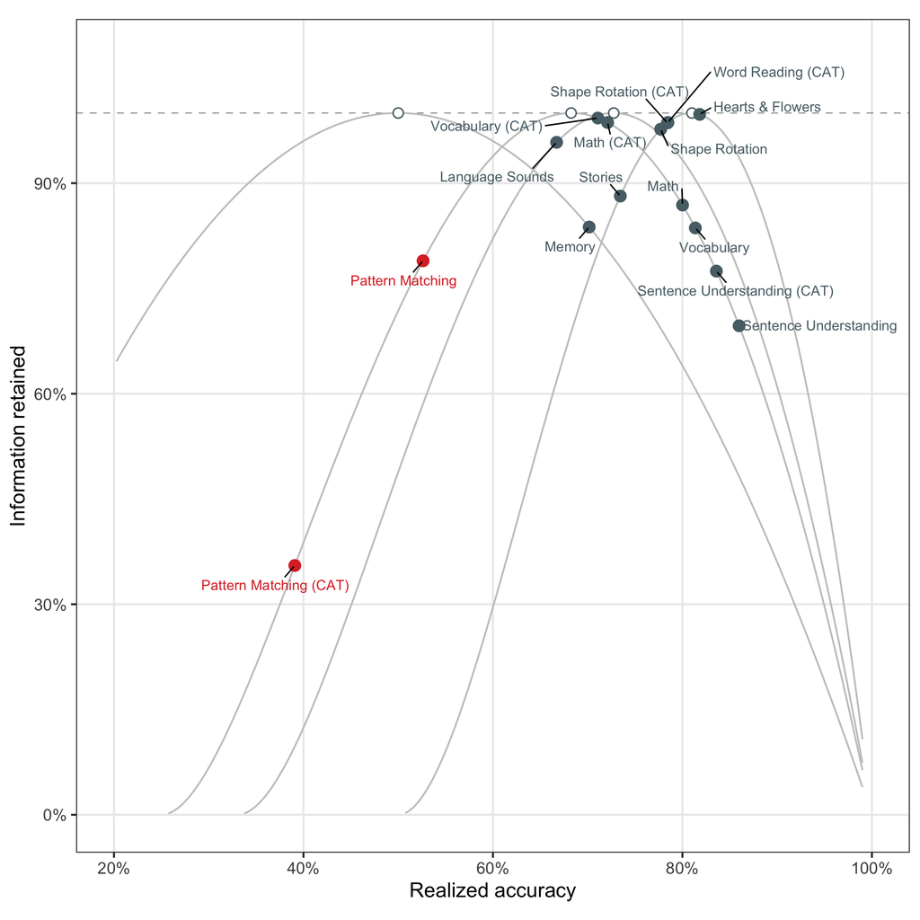

Figure 1: Fisher information as a share of each response format’s own maximum, against realized accuracy. Grey curves are the formats (open circles mark each one’s optimum: 50% with no guessing, 68% for 4-choice, 81% for 2-choice). Every calibrated task × variant sits on the curve for its own format. Points left of a curve’s peak run harder than optimal, points right of it run easier. Pattern Matching in red.

```r
fmt_curves <- tibble(g = sort(unique(placement_all$g_use))) |>
  rowwise() |> mutate(p_opt = p_opt_f(g), I_opt = info_at_p(p_opt, g)) |> ungroup() |>
  crossing(p = seq(.02, .99, by = .0025)) |> filter(p > g + .005) |>
  mutate(kept = info_at_p(p, g) / I_opt)

fmt_opt <- fmt_curves |> group_by(g) |> slice_max(kept, n = 1, with_ties = FALSE) |> ungroup()

pl <- placement_all |>
  mutate(lab = paste0(task, if_else(Mode == "CAT", " (CAT)", "")),
         focal = task == "Pattern Matching")

ggplot() +
  geom_hline(yintercept = 1, linetype = "dashed", colour = GREY, linewidth = .3) +
  geom_line(data = fmt_curves, aes(p, kept, group = g), colour = "grey78", linewidth = .5) +
  geom_point(data = fmt_opt, aes(p, kept), shape = 21, fill = "white",
             colour = DARK, size = 2.4, stroke = .6) +
  geom_point(data = pl, aes(realized_acc, info_kept, colour = focal), size = 2.8) +
  ggrepel::geom_text_repel(data = pl, aes(realized_acc, info_kept, label = lab, colour = focal),
                           size = 2.9, min.segment.length = 0, box.padding = .5,
                           segment.size = .4, segment.colour = "black", seed = 7,
                           max.overlaps = 30) +
  scale_colour_manual(values = c(`TRUE` = RED, `FALSE` = DARK), guide = "none") +
  scale_x_continuous("Realized accuracy", labels = scales::percent_format(1),
                     limits = c(.2, 1)) +
  scale_y_continuous("Information retained", labels = scales::percent_format(1),
                     limits = c(0, 1.08)) +
  theme(aspect.ratio = 1)
```

The same cells as numbers, sorted by how much information each retains:

```r
placement_all |>
  transmute(Task = task, Mode, Realized = sprintf("%.0f%%", 100*realized_acc),
            `Own optimum` = sprintf("%.0f%%", 100*p_star),
            `Targeting efficiency` = sprintf("%.0f%%", 100*info_kept),
            Items = median_trials, `Effective items` = sprintf("%.0f", eff_items),
            `Rel. from .90` = sprintf("%.3f", rel_from_90)) |>
  kable(align = "llrrrrrr")
```

| Task | Mode | Realized | Own optimum | Targeting efficiency | Items | Effective items | Rel. from .90 |
| --- | --- | --- | --- | --- | --- | --- | --- |
| Hearts & Flowers | non-adaptive | 82% | 81% | 100% | 60 | 60 | 0.900 |
| Memory | non-adaptive | 70% | 50% | 84% | 20 | 17 | 0.883 |
| Math | CAT | 72% | 68% | 99% | 40 | 39 | 0.899 |
| Math | non-adaptive | 80% | 68% | 87% | 90 | 78 | 0.887 |
| Pattern Matching | CAT | 39% | 68% | 36% | 31 | 11 | 0.762 |
| Pattern Matching | non-adaptive | 53% | 68% | 79% | 22 | 17 | 0.877 |
| Shape Rotation | CAT | 78% | 81% | 99% | 27 | 27 | 0.899 |
| Shape Rotation | non-adaptive | 78% | 81% | 98% | 67 | 65 | 0.898 |
| Sentence Understanding | CAT | 84% | 68% | 77% | 40 | 31 | 0.875 |
| Sentence Understanding | non-adaptive | 86% | 68% | 70% | 86 | 60 | 0.862 |
| Vocabulary | CAT | 71% | 68% | 99% | 46 | 46 | 0.899 |
| Vocabulary | non-adaptive | 81% | 68% | 84% | 122 | 102 | 0.883 |
| Stories | non-adaptive | 73% | 81% | 88% | 28 | 25 | 0.888 |
| Language Sounds | non-adaptive | 67% | 73% | 96% | 20 | 19 | 0.896 |
| Word Reading | CAT | 78% | 81% | 99% | 120 | 118 | 0.899 |

Table 2: Every calibrated task × variant cell against its own model’s information optimum, with the resulting effective test length and reliability.

**Note“Targeting efficiency” is one of two things you might mean**

The column above evaluates information **at the task’s mean success rate** — it answers *“is this task aimed at the right place?”*

A different question is *“how much information does it actually collect?”*, which averages information **over the items actually served**, each at its own expected accuracy. Because information is concave in $p$, the average of $I(p_i)$ is always below $I(\bar p)$ — Jensen’s inequality — and the gap is the price of within-run dispersion.

Script 42 computes both with each item’s **own** guessing floor, which gives lower absolute numbers than the single task-level floor behind the table above (its targeting efficiency for Pattern Matching CAT is 21% against the table’s 36% — so compare script 42’s two numbers to each other, not to the table). Realized information efficiency runs **33–57%** across tasks even where targeting efficiency is 99%. The gap is smallest for Pattern Matching CAT (21% → 20%) precisely because it is *uniformly* badly aimed, leaving little dispersion to lose. Both are real; they answer different questions.

## Pattern Matching: the bank problem

- Lowest realized accuracy in the battery: **.391 under CAT**, .526 fixed-form (4-choice, chance .25). **Ages 5–7 realize .31–.33 — barely above chance.**
- **The only adaptive task serving items above the child**: median gap **+2.36 logits**; every other adaptive task −0.70 to −4.02. The 4-choice optimum is −0.31.
- **Targeting, not disengagement**: realized .391 $\approx$ expected-if-fully-engaged .452.
- **The bank**: median item +1.97 vs median child $\theta$ −0.68; 12 of 151 items below −1 while a quarter of children sit below −2.2. **13.5% of runs have no item at $p \geq .70$.**

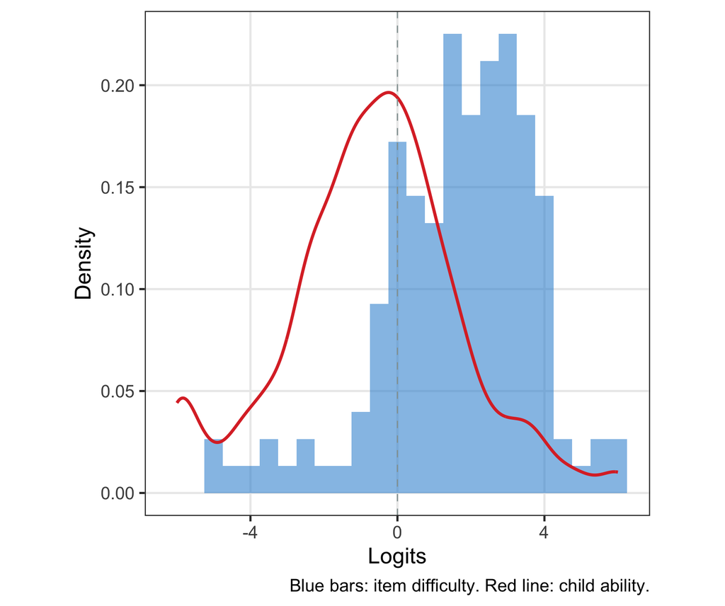

Figure 2: The bank problem in one picture: Pattern Matching’s item difficulties (blue bars) against the ability of the children taking it (red line). The bank’s mass sits above nearly the whole population — the CAT has almost nothing to serve where the children are. Every other task’s bank sits below its children (Section 10).

```r
read_csv(file.path(PROJ, "processed_data/44_bank_ability.csv"),
         show_col_types = FALSE) |>
  filter(task_id == "matrix-reasoning", value > -8, value < 8) |>
  ggplot() +
  geom_histogram(data = \(d) filter(d, what == "item difficulty"),
                 aes(value, after_stat(density)), binwidth = .5,
                 fill = BLUE, alpha = .55) +
  geom_density(data = \(d) filter(d, what == "child ability"), aes(value),
               colour = RED, linewidth = .8) +
  geom_vline(xintercept = 0, colour = GREY, linewidth = .3, linetype = "dashed") +
  labs(x = "Logits", y = "Density",
       caption = "Blue bars: item difficulty. Red line: child ability.") +
  theme(aspect.ratio = 1)
```

## Why is the CAT *worse* than the fixed form here?

Pattern Matching realizes **.39 under CAT against .53 fixed-form**. An adaptive algorithm doing worse than a static one is surprising enough to check.

**It is not a stopping-rule artifact.** Fixed-form runs are shorter (median 22 trials vs 31), so one explanation would be that discontinue-rule truncation removes the hard tail from the fixed form’s average. Matching on trial count kills that: over the **first 10 trials** the fixed form runs .690 against the CAT’s .461; over the first 20, .569 against .421 (run-weighted; script 75). The gap is there from the opening trials.

**The trajectories are the diagnostic** (script 75, run-weighted):

```r
read_csv(file.path(PROJ, "processed_data/75_quintile_accuracy.csv"),
         show_col_types = FALSE) |>
  filter(task_id == "matrix-reasoning", weighting == "run-weighted") |>
  select(variant, q, accuracy) |>
  pivot_wider(names_from = q, values_from = accuracy, names_prefix = "Quintile ") |>
  mutate(across(where(is.numeric), \(x) sprintf("%.3f", x))) |>
  rename(Variant = variant) |> kable(align = "lrrrrr")
```

| Variant | Quintile 1 | Quintile 2 | Quintile 3 | Quintile 4 | Quintile 5 |
| --- | --- | --- | --- | --- | --- |
| CAT | 0.446 | 0.441 | 0.391 | 0.354 | 0.312 |
| fixed | 0.836 | 0.614 | 0.471 | 0.428 | 0.203 |

Table 3: Accuracy by within-run quintile, Pattern Matching (run-weighted; script 75). The fixed form opens easy and gets harder — a normal easy-to-hard ordering. The CAT declines monotonically, which is not what a converging CAT does; accuracy should stabilize near the target as θ is pinned down.

**ImportantThe CAT knows where the child is — and has nothing to serve there**

Reading the deployed CAT’s own per-trial $\theta$ trace against the difficulty of the item actually served, by within-run quintile (medians, logits; script 75): **the trace is flat near −2.3 while served difficulty climbs from +0.7 to +2.1** — the gap between what the algorithm wants and what the bank has widens from ~3 to ~4.5 logits over the run. For comparison, Vocabulary CAT’s served difficulty *converges onto* its trace (trace 0 → −0.72 while served moves −0.99 → −0.69), which is what working targeting looks like.

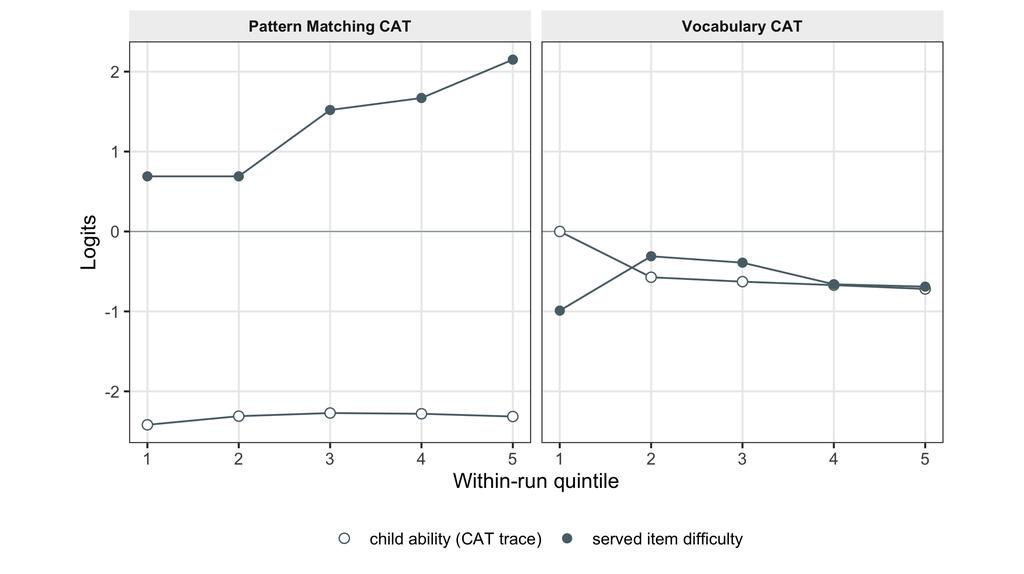

Figure 3: The deployed CAT’s running ability estimate (open) against the difficulty it serves (filled), by within-run quintile, medians in logits (script 75).

```r
read_csv(file.path(PROJ, "processed_data/75_quintile_theta.csv"),
         show_col_types = FALSE) |>
  mutate(Task = recode(task_id, `matrix-reasoning` = "Pattern Matching CAT",
                       vocab = "Vocabulary CAT")) |>
  select(Task, q, `child ability (CAT trace)` = median_theta_trace,
         `served item difficulty` = median_served_b) |>
  pivot_longer(-c(Task, q), names_to = "series", values_to = "logits") |>
  ggplot(aes(q, logits, shape = series, group = series)) +
  geom_hline(yintercept = 0, linewidth = .3, colour = GREY) +
  geom_line(linewidth = .5, colour = DARK) +
  geom_point(size = 2.4, colour = DARK, fill = "white") +
  scale_shape_manual(values = c(`child ability (CAT trace)` = 21,
                                `served item difficulty` = 16), name = NULL) +
  facet_wrap(~ Task) +
  scale_x_continuous("Within-run quintile") +
  scale_y_continuous("Logits") +
  theme(aspect.ratio = 1, legend.position = "bottom")
```

**Item repeats are not the cause** — 0% of Pattern Matching items repeat within a run, so exposure control is not forcing the selector upward.

The explanation most consistent with these numbers is **bank exhaustion at the easy end**: the CAT wants items near $\theta$, spends the handful available below −1 logit in the opening trials, and then has nowhere to go but up into the bank’s hard mass (median +1.97). The fixed form avoids this because its easy-to-hard ordering guarantees every child a genuinely easy opening block.

This is a mechanical consequence of the bank, not evidence that jsCat is misimplemented — but it is worth putting to the DCC, and it makes the bank-extension case considerably stronger than “some children have no easy items.” The CAT **deteriorates within a run** because it runs out of floor.

**NoteWhy the existing CAT simulations would not have caught this**

`levante-pilots/03_summaries/cat_simu.qmd` simulates CAT performance by drawing simulees from $\theta \sim N(0,1)$ and fitting a Rasch model to the same generated data. That design assumes the population is centred on the item bank. **A bank–population mismatch is exactly the failure mode it cannot surface**: the simulated children sit where the items are, so the easy end never runs out. Real Pattern Matching children have a median $\theta$ of −0.68 against a median item difficulty of +1.97, with 10% below −3.65.

Adding a simulation condition where simulee $\theta$ is drawn from the *observed* ability distribution rather than a standard normal would catch this class of problem before deployment, and is cheap to do.

**Would starting harder fix it?** No — and the direction is the opposite. The chain is: the $\theta = 0$ start sits above most young children, they fail the opening items, the ML estimate drops sharply, the CAT then asks for very easy items and burns the handful that exist. Starting *harder* accelerates every step of that. Starting **easier or age-appropriate** would reduce the early failures and the overshoot, so the scarce easy items would last longer — a real but partial mitigation. **No start value creates items.** With 12 items below −1 logit for a population where a quarter of children sit below −2.2, the bank is the binding constraint and the start value is a second-order fix.

# What easiness costs

Section 6 showed that most tasks sit near their own optimum and one sits far off it. That raises the practical question this section answers: **if we deliberately moved a task easier than its information optimum, what would we give up?**

The answer has to be in a currency people can act on. “Fisher information” is the technically correct unit and means nothing to anyone reading a results table, so everything below is converted into **reliability** — the quantity the core-tasks manuscript already reports — and into **effective test length**, the number of items a shortened-information test measures like.

The conversion is a two-step. Information falls as accuracy moves away from the optimum, by a factor $c = I(p^\star)/I(p)$. Error variance scales by that same factor, so with true-score variance held fixed a test that started at reliability $r_0$ ends at $r_{new} = r_0/(r_0 + c(1-r_0))$. Everything is computed for an idealized CAT serving every item at the target gap, with discrimination fixed at 1 — the same model as Section 4, so the numbers are comparable throughout.

**NoteThe .90 starting point is generous for several tasks**

Everything below starts a test at $r_0 = .90$, which makes the *relative* cost of a friendlier target easy to read but overstates the absolute reliability of some tasks. The core-tasks paper’s own estimates (`levante-pilots/02_scoring_outputs/task_rxx.rds`, restricted to the model `mods_best.rds` selects) give median reliability across the three sites of Memory .94, Same & Different .90, Math .85, Shape Rotation .78, Sentence Understanding .73, **Pattern Matching .62** and Hearts & Flowers .43. Pattern Matching is the task this document argues hardest about, and its deployed model sits near .62, not .90 — so read the reliability columns as the price of a target, not as a forecast of what any particular task would achieve.

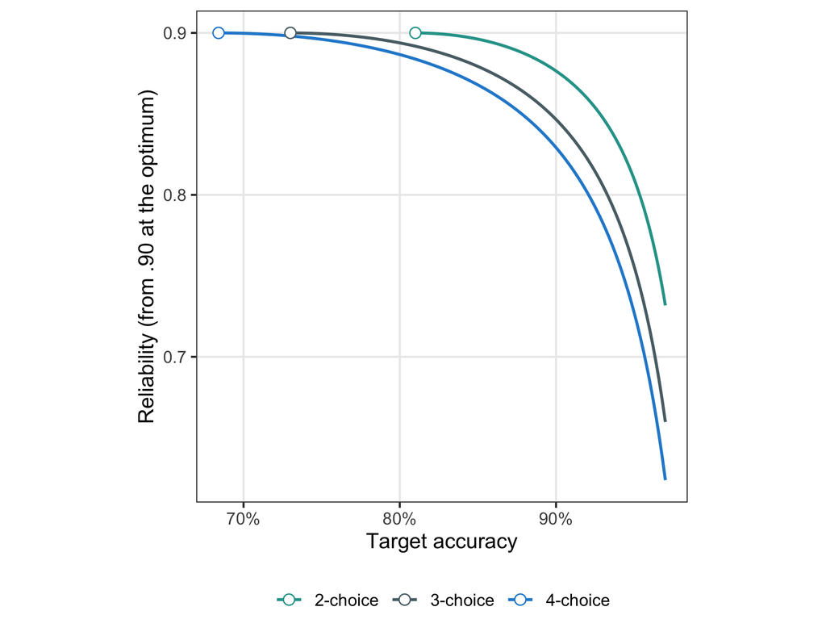

Figure 4: Reliability against target accuracy at fixed test length, for a test that starts at .90 when perfectly targeted. Each curve begins at its own format’s optimum (open circle). The cost is flat for the first several points and then accelerates — which is the whole argument for moving a little and stopping.

```r
cost_curve <- tibble(format = c("2-choice","3-choice","4-choice"), g = c(.5, 1/3, .25)) |>
  rowwise() |> mutate(p_opt = p_opt_f(g)) |> ungroup() |>
  crossing(target = seq(.45, .97, by = .002)) |>
  filter(target >= p_opt) |>
  mutate(c = info_at_p(p_opt, g)/info_at_p(target, g), rel90 = .90/(.90 + c*.10))

ggplot(cost_curve, aes(target, rel90, colour = format)) +
  geom_line(linewidth = .8) +
  geom_point(data = cost_curve |> group_by(format) |> slice_min(target, n = 1),
             shape = 21, fill = "white", size = 2.6) +
  scale_colour_manual(values = c("4-choice" = BLUE, "3-choice" = DARK,
                                 "2-choice" = "#2aa198"), name = NULL) +
  scale_x_continuous("Target accuracy", labels = scales::percent_format(1)) +
  scale_y_continuous("Reliability (from .90 at the optimum)") +
  theme(aspect.ratio = 1, legend.position = "bottom")
```

The same trade-off as numbers, including effective test length:

```r
fixed_len <- tibble(format = c("2-choice","3-choice","4-choice"), g = c(.5, 1/3, .25)) |>
  rowwise() |> mutate(p_opt = p_opt_f(g)) |> ungroup() |>
  crossing(target = c(.70,.75,.80,.85,.90,.95)) |> filter(target > p_opt + .001) |>
  mutate(c = info_at_p(p_opt,g)/info_at_p(target,g), info_kept = 1/c,
         se_infl = sqrt(c)-1, eff30 = 30/c, rel90 = .90/(.90+c*.10), rel80 = .80/(.80+c*.20))

fixed_len |>
  transmute(Format = format,
            Optimum = sprintf("%.0f%%", 100*p_opt),
            Target = sprintf("%.0f%%", 100*target),
            `Info kept` = sprintf("%.0f%%", 100*info_kept),
            `Effective items (of 30)` = sprintf("%.1f", eff30),
            `Reliability, from .90` = sprintf("%.3f", rel90),
            `from .80` = sprintf("%.3f", rel80)) |> kable(align = "llrrrrr")
```

| Format | Optimum | Target | Info kept | Effective items (of 30) | Reliability, from .90 | from .80 |
| --- | --- | --- | --- | --- | --- | --- |
| 2-choice | 81% | 85% | 96% | 28.8 | 0.896 | 0.793 |
| 2-choice | 81% | 90% | 79% | 23.7 | 0.877 | 0.759 |
| 2-choice | 81% | 95% | 47% | 14.2 | 0.810 | 0.654 |
| 3-choice | 73% | 75% | 99% | 29.8 | 0.899 | 0.799 |
| 3-choice | 73% | 80% | 94% | 28.1 | 0.894 | 0.789 |
| 3-choice | 73% | 85% | 81% | 24.3 | 0.879 | 0.764 |
| 3-choice | 73% | 90% | 61% | 18.4 | 0.847 | 0.710 |
| 3-choice | 73% | 95% | 34% | 10.3 | 0.756 | 0.579 |
| 4-choice | 68% | 70% | 100% | 29.9 | 0.900 | 0.800 |
| 4-choice | 68% | 75% | 96% | 28.7 | 0.896 | 0.793 |
| 4-choice | 68% | 80% | 87% | 26.1 | 0.887 | 0.777 |
| 4-choice | 68% | 85% | 73% | 21.9 | 0.868 | 0.745 |
| 4-choice | 68% | 90% | 54% | 16.2 | 0.829 | 0.683 |
| 4-choice | 68% | 95% | 30% | 8.9 | 0.727 | 0.542 |

Table 4: What an easier target costs at fixed test length, by response format.

**The lesson.** Easiness is close to free near the optimum and expensive past it. On a 4-choice task, moving from 68% to 75% costs about 4% of the information — a reliability of .90 becomes .896, which nobody would notice. Moving to 85% costs 27%, taking .90 down to .868 and making a 30-item test measure like a 22-item one. The decision point is somewhere in the high seventies to low eighties, not at 90%.

## What adding items buys, every task

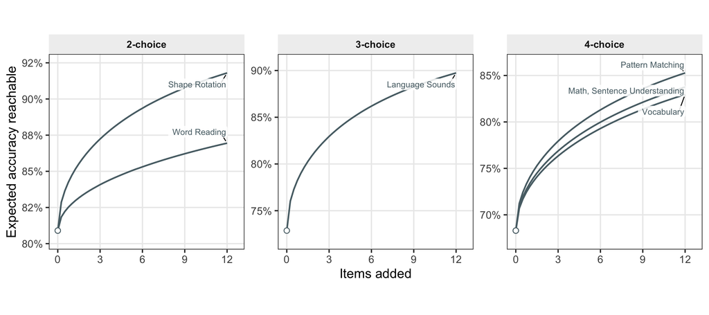

Figure 5: How much extra test length buys, by response format. Each panel is one format, starting from its own information optimum (the open circle at zero items added). Curves are tasks at their actual median CAT length. Math and Sentence Understanding share a curve — identical length and format. Language Sounds is not currently adaptive and is shown at its 20-item length only to represent the 3-choice format, which no deployed CAT uses. Same & Different is excluded throughout.

```r
# Math and Sentence Understanding have identical length and format, so their curves
# coincide exactly — they share one label rather than overplotting two.
add_dat <- tibble(
  task = c("Pattern Matching","Math, Sentence Understanding","Vocabulary",
           "Shape Rotation","Word Reading","Language Sounds"),
  n_items = c(31, 40, 46, 27, 120, 20),
  g = c(.25, .25, .25, .5, .5, 1/3)) |>
  mutate(Format = case_when(g == .5 ~ "2-choice", g == .25 ~ "4-choice",
                            TRUE ~ "3-choice"),
         Format = factor(Format, levels = c("2-choice","3-choice","4-choice"))) |>
  crossing(extra = seq(0, 12, by = .25)) |>
  rowwise() |>
  mutate(p_opt = p_opt_f(g),
         p_reach = if (extra == 0) p_opt else
           uniroot(\(p) info_at_p(p, g) - info_at_p(p_opt, g) * n_items/(n_items + extra),
                   c(p_opt + 1e-9, 1 - 1e-6))$root) |>
  ungroup()

add_lab <- add_dat |> group_by(task) |> slice_max(extra, n = 1) |> ungroup()

ggplot(add_dat, aes(extra, p_reach, group = task)) +
  geom_line(linewidth = .7, colour = DARK) +
  geom_point(data = add_dat |> filter(extra == 0), size = 2,
             shape = 21, fill = "white", colour = DARK) +
  ggrepel::geom_label_repel(
    data = add_lab, aes(label = task),
    size = 2.7, colour = DARK, hjust = 1, direction = "y",
    nudge_x = -0.4, box.padding = .3, point.padding = .2,
    min.segment.length = 0, segment.size = .4, segment.colour = "black",
    xlim = c(NA, 12.2), seed = 1,
    fill = alpha("white", .85), label.size = 0, label.padding = unit(.9, "mm")) +
  facet_wrap(~ Format, scales = "free_y") +
  scale_x_continuous("Items added", breaks = seq(0, 12, 3),
                     limits = c(0, 12.6)) +
  scale_y_continuous("Expected accuracy reachable",
                     labels = scales::percent_format(1),
                     expand = expansion(mult = .12)) +
  theme(aspect.ratio = 1, legend.position = "none")
```

# Engagement: does success rate move it, beyond ability?

The question needs within-child variation: children of the same ability experiencing different success rates. Run-level regressions cannot supply it — a CAT’s whole job is to erase exactly that variation, and after partialling ability the served success rate varies by ~0.026 SD within a task × variant cell. So the test is run at the **trial level**: within a single child’s single run, does behavior degrade on the trials that are too hard? Run fixed effects absorb ability, site, epoch, age, and ability-estimation error at once; a cubic in within-run position separates difficulty from fatigue (script 76).

The outcome is **rapid guessing** — the one engagement measure whose validation is internal (rapid-flagged trials score at chance; solution-behavior trials score far above it) rather than assumed.

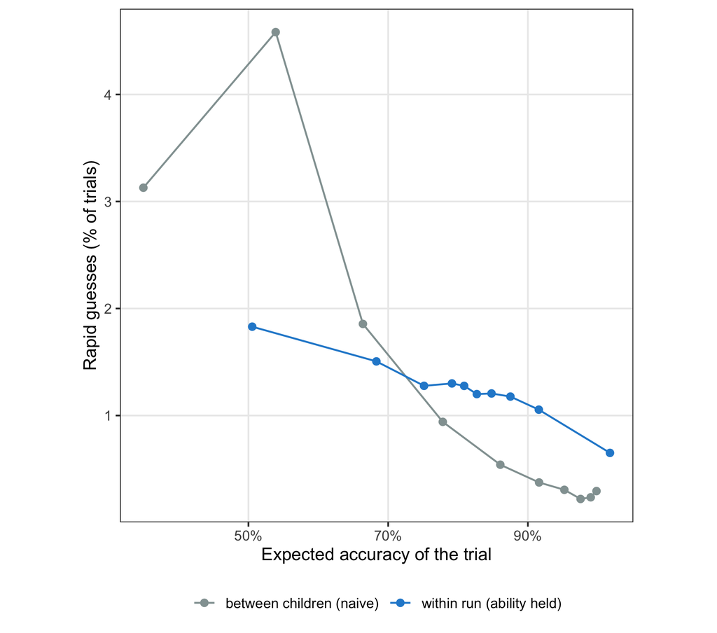

Figure 6: P(rapid guess) by decile of the trial’s expected accuracy, pooled across the battery: 713,953 trials from eight tasks (Hearts & Flowers, Math, Pattern Matching, Shape Rotation, Sentence Understanding, Vocabulary, Stories, Word Reading — both variants, all sites and ages; clean-data runs with ≥10 usable trials; Language Sounds excluded because NT10 fails validation there, Memory has no response times, Sentence Reading is not IRT, Same & Different is yoked). Grey: the raw between-children relationship (all variation, including ability). Blue: within run — each run’s mean removed (run fixed effects), recentered at the grand mean. The naive curve is steeper and non-monotone because hard trials belong disproportionately to struggling children; the within-run curve is the defensible quantity. The curves cross at the right because able children’s low overall rapid rates flatter the naive curve on easy trials. The naive curve’s hump at ~50% is format composition at the guessing floor: 2-choice tasks cannot fall below their g = .5 floor, so the bin below 50% is 93% three/four-choice trials, while the bin just above is 70% two-choice — 42% of it the hardest Word Reading trials, from young readers with the battery’s highest rapid rates (script 84). The per-task version is the faceted figure below. Scripts 76/82/84.

```r
read_csv(file.path(PROJ, "processed_data/82a_bins.csv"), show_col_types = FALSE) |>
  ggplot(aes(x, y, colour = series)) +
  geom_line(linewidth = .6) + geom_point(size = 2) +
  scale_colour_manual(values = c(`between children (naive)` = GREY,
                                 `within run (ability held)` = BLUE), name = NULL) +
  scale_x_continuous("Expected accuracy of the trial",
                     labels = scales::percent_format(1)) +
  scale_y_continuous("Rapid guesses (% of trials)") +
  theme(aspect.ratio = 1, legend.position = "bottom")
```

```r
read_csv(file.path(PROJ, "processed_data/76_trial_dose_primary.csv"),
         show_col_types = FALSE) |>
  transmute(Model = model, Outcome = outcome,
            `β (pp per unit p_exp)` = sprintf("%+.1f", 100*beta_p_exp),
            SE = sprintf("%.2f", 100*se),
            p = fmt_p(p)) |>
  kable(align = "llrrr")
```

| Model | Outcome | β (pp per unit p_exp) | SE | p |
| --- | --- | --- | --- | --- |
| PRIMARY: run FE + position | rapid | -1.5 | 0.13 | <.001 |
| run FE, no position | rapid | -2.2 | 0.14 | <.001 |
| naive: poly(theta,3), no FE | rapid | -3.6 | 0.24 | <.001 |
| robust: task-constant NT10 threshold | rapid_taskth | -0.5 | 0.11 | <.001 |
| robust: absolute < 500 ms | rapid_500 | +1.1 | 0.14 | <.001 |
| robust: absolute < 1000 ms | rapid_1000 | +10.5 | 0.38 | <.001 |
| secondary: run FE + position | rt_z | -166.7 | 1.52 | <.001 |

Table 5: The primary test and its robustness ladder (script 76; n = 714k trials, SEs clustered by run). β = change in P(rapid) from expected accuracy 0 → 1. The task-constant threshold cannot scale with item difficulty and its residual bias runs AGAINST the hypothesis — its surviving negative coefficient is the conservative bound. Absolute thresholds flip sign because sub-second answers on easy items are mostly legitimate fast answers, which is what the item-relative NT10 threshold exists to handle.

## The same relationship, task by task and age by age

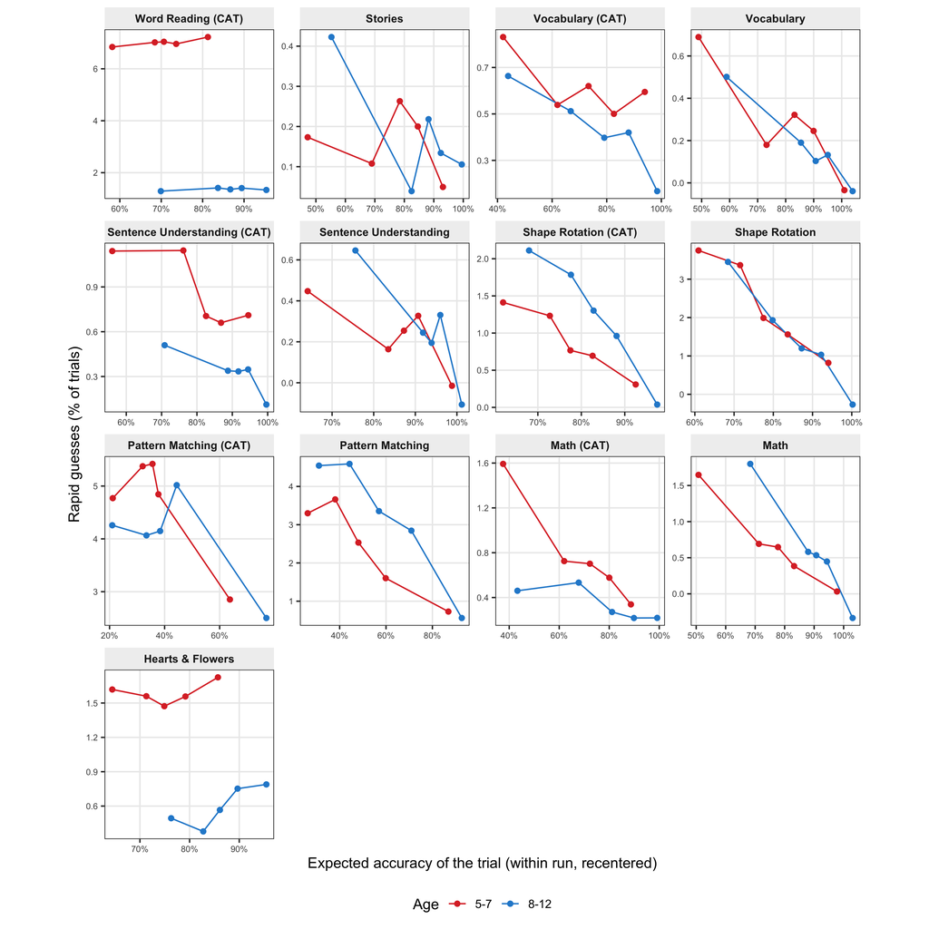

Figure 7: The within-run relationship per task × variant cell, by age band: P(rapid) against the trial’s expected accuracy, both demeaned within run and recentered at the cell mean, five bins per cell. Cells with at least 4,000 trials (script 85 has the full count table). Language Sounds excluded throughout (NT10 fails its chance validation there); Memory has no response times; Same & Different is yoked. Script 83.

```r
bins <- read_csv(file.path(PROJ, "processed_data/83_cell_bins.csv"),
                 show_col_types = FALSE) |>
  mutate(Task = unname(pretty_task[task_id]),
         cell = paste0(Task, if_else(variant == "CAT", " (CAT)", "")),
         cell = fct_reorder2(cell, as.integer(ord_task(Task)),
                             as.integer(variant == "CAT"), .fun = \(a, b) a[1]*10 + b[1]))
ggplot(bins, aes(x, y, colour = age_band)) +
  geom_line(linewidth = .55) + geom_point(size = 1.7) +
  facet_wrap(~ cell, ncol = 4, scales = "free") +
  scale_colour_manual(values = c(`5-7` = RED, `8-12` = BLUE)) +
  scale_x_continuous("Expected accuracy of the trial (within run, recentered)",
                     labels = scales::percent_format(1)) +
  labs(y = "Rapid guesses (% of trials)", colour = "Age") +
  theme(aspect.ratio = 1, legend.position = "bottom",
        axis.text = element_text(size = 7))
```

```r
read_csv(file.path(PROJ, "processed_data/83_cell_slopes.csv"),
         show_col_types = FALSE) |>
  mutate(Task = unname(pretty_task[task_id])) |>
  transmute(Task, Mode = variant, Age = age_band, Runs = n_runs,
            `β (pp)` = sprintf("%+.1f", 100*beta),
            `p (BH)` = fmt_p(p_bh),
            Sig = if_else(p_bh < .05, "✓", "")) |>
  arrange(ord_task(Task), desc(Mode), Age) |> kable(align = "lllrrrc")
```

| Task | Mode | Age | Runs | β (pp) | p (BH) | Sig |
| --- | --- | --- | --- | --- | --- | --- |
| Hearts & Flowers | non-adaptive | 5-7 | 505 | -0.2 | 0.941 |  |
| Hearts & Flowers | non-adaptive | 8-12 | 830 | +1.6 | 0.291 |  |
| Math | non-adaptive | 5-7 | 321 | -2.0 | 0.008 | ✓ |
| Math | non-adaptive | 8-12 | 710 | -5.4 | <.001 | ✓ |
| Math | CAT | 5-7 | 350 | -1.7 | 0.008 | ✓ |
| Math | CAT | 8-12 | 936 | -0.6 | 0.004 | ✓ |
| Pattern Matching | non-adaptive | 5-7 | 196 | -3.1 | 0.092 |  |
| Pattern Matching | non-adaptive | 8-12 | 387 | -2.8 | <.001 | ✓ |
| Pattern Matching | CAT | 5-7 | 222 | -3.5 | 0.002 | ✓ |
| Pattern Matching | CAT | 8-12 | 513 | -2.0 | <.001 | ✓ |
| Shape Rotation | non-adaptive | 5-7 | 171 | -2.5 | 0.178 |  |
| Shape Rotation | non-adaptive | 8-12 | 416 | -5.4 | 0.003 | ✓ |
| Shape Rotation | CAT | 5-7 | 246 | -3.1 | 0.254 |  |
| Shape Rotation | CAT | 8-12 | 472 | -6.3 | 0.016 | ✓ |
| Sentence Understanding | non-adaptive | 5-7 | 191 | -0.8 | 0.122 |  |
| Sentence Understanding | non-adaptive | 8-12 | 256 | -1.5 | 0.086 |  |
| Sentence Understanding | CAT | 5-7 | 271 | -0.9 | 0.040 | ✓ |
| Sentence Understanding | CAT | 8-12 | 700 | -1.0 | 0.067 |  |
| Vocabulary | non-adaptive | 5-7 | 133 | -0.9 | 0.089 |  |
| Vocabulary | non-adaptive | 8-12 | 218 | -0.8 | 0.055 |  |
| Vocabulary | CAT | 5-7 | 350 | -0.4 | 0.156 |  |
| Vocabulary | CAT | 8-12 | 708 | -0.8 | 0.156 |  |
| Stories | non-adaptive | 5-7 | 353 | -0.0 | 0.760 |  |
| Stories | non-adaptive | 8-12 | 559 | -0.4 | 0.082 |  |
| Word Reading | CAT | 5-7 | 308 | +0.9 | 0.426 |  |
| Word Reading | CAT | 8-12 | 1327 | -0.0 | 0.941 |  |

Table 6: Per-cell within-run slopes (rapid ~ expected accuracy + position | run FE; descriptive, BH across cells; the pooled test above is the declared primary). Negative = harder trials → more rapid guessing.

Three readings. **The effect is battery-wide but not universal** — 24 of 26 cells negative, 10 surviving BH, concentrated in the multi-choice core tasks. **The nulls are the right nulls**: Word Reading (ROAR’s own CAT already serving below the child), Hearts & Flowers (at its optimum, and a speeded 2-choice task where NT10 behaves differently), and Stories 5–7. **Both age bands carry it** — including 8–12, where run-level rapid rates sit under 1% and looked floor-limited; within-child identification recovers the signal the floor hid.

Two objections a skeptical reader should raise here — that the analysis is circular, and that an engaged child could produce the pattern mechanically — are tested and ruled out in Section 15 toward the end of the document.

# Where the optimum is

Two facts set the recommendation, and neither requires locating a peak:

1. **Engagement improves monotonically toward easier** across the observed range in nearly every cell (Section 8). Quadratic-vertex analyses were run and cannot support a located turnover — the cells that turn over inside their observed range are few, their vertices sit near range edges, and the accuracy-model measures (person fit, the mixture weight π) peak at the information optimum because that is where those statistics are best behaved, which is the method confirming itself rather than an engagement finding.
2. **The information cost is analytic and its knee is at ~80%** (Section 7): 75% costs 4% of information, 80% costs 13%, 85% costs 27%.

```r
read_csv(file.path(PROJ, "processed_data/47_target_cost.csv"), show_col_types = FALSE) |>
  filter(format == "4-choice", target >= .70) |>
  transmute(`Target accuracy` = sprintf("%.0f%%", 100*target),
            `Information kept` = sprintf("%.0f%%", 100*info_kept),
            `Reliability, from .90` = sprintf("%.3f", rel90),
            `30 items behave like` = sprintf("%.1f items", eff30)) |>
  kable(align = "lrrr")
```

What each target accuracy costs on a 4-choice task at fixed test length, in information, reliability, and effective items.

| Target accuracy | Information kept | Reliability, from .90 | 30 items behave like |
| --- | --- | --- | --- |
| 70% | 100% | 0.900 | 29.9 items |
| 75% | 96% | 0.896 | 28.7 items |
| 80% | 87% | 0.887 | 26.1 items |
| 85% | 73% | 0.868 | 21.9 items |
| 90% | 54% | 0.829 | 16.2 items |
| 95% | 30% | 0.727 | 8.9 items |

**ImportantThe recommendation this points to**

For a 4-choice task, **target somewhere in the 75–80% band**.

- At **75%** you keep **96%** of the information (reliability .90 → .896). This is close to free.
- At **80%** you keep **87%** (reliability .90 → .887). A reliability cost of .013 is small against what the manuscript already reports.
- At **85%** the cost accelerates — 73% of information, reliability .868 — for an engagement benefit the observational data cannot certify.

Note what this is *not*: it is not “as easy as possible.” The engagement argument licenses moving roughly 10 points above the information optimum and stopping; where above the band the benefit turns over is precisely what the sweep (Section 14) measures, and the observational data cannot locate it.

# The math downward extension

Mike’s question: *is it too hard, does it ramp too quickly, and is this because we don’t have enough easy trials?* Three separable claims, so they get three separate tests. Pattern Matching is carried alongside throughout as the known-broken contrast.

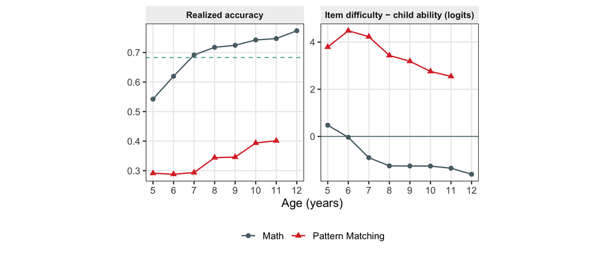

Figure 8: Math and Pattern Matching CAT across age. Realized accuracy against each format’s 68% optimum (dashed), and the gap between the difficulty of the items served and the child’s own ability — positive means the CAT is serving items above the child. Ages with fewer than 15 runs are dropped.

```r
by_age <- rt_tr |>
  filter(is_adaptive, task_id %in% c("egma-math","matrix-reasoning"), age >= 5, age <= 12) |>
  group_by(Task = unname(pretty_task[task_id]), Age = floor(age)) |>
  summarise(Runs = n_distinct(run_id), Accuracy = mean(correct),
            `Median child θ` = median(theta), `Median gap` = median(gap),
            `Rapid %` = 100*mean(rapid), .groups = "drop") |> filter(Runs >= 15)

by_age |>
  select(Task, Age, `Realized accuracy` = Accuracy,
         `Item difficulty − child ability (logits)` = `Median gap`) |>
  pivot_longer(-c(Task, Age), names_to = "Measure", values_to = "v") |>
  mutate(Measure = fct_inorder(Measure)) |>
  ggplot(aes(Age, v, colour = Task, shape = Task)) +
  geom_hline(data = tibble(Measure = factor("Item difficulty − child ability (logits)",
                                            levels = c("Realized accuracy",
                                                       "Item difficulty − child ability (logits)")),
                           yint = 0),
             aes(yintercept = yint), colour = DARK, linewidth = .4) +
  geom_hline(data = tibble(Measure = factor("Realized accuracy",
                                            levels = c("Realized accuracy",
                                                       "Item difficulty − child ability (logits)")),
                           yint = p_opt_f(.25)),
             aes(yintercept = yint), colour = GREEN, linetype = "dashed", linewidth = .4) +
  geom_line(linewidth = .6) + geom_point(size = 2) +
  facet_wrap(~ Measure, scales = "free_y") +
  scale_colour_manual(values = c(`Math` = DARK, `Pattern Matching` = RED)) +
  scale_x_continuous(breaks = 5:12) +
  labs(x = "Age (years)", y = NULL, colour = NULL, shape = NULL) +
  theme(legend.position = "bottom", aspect.ratio = 1)
```

**NoteWhy $p \geq .60$ in the table below?**

“The first trial on which the item presented had an expected accuracy of at least 60% for that child.” 60% is deliberately lenient — it sits *below* every format’s optimum (68 / 73 / 81%), so reaching it does not mean the CAT is well targeted, only that it has stopped serving items the child will probably fail. A floor, not a goal.

```r
rt_tr |>
  filter(is_adaptive, task_id %in% c("egma-math","matrix-reasoning"), age >= 5, age <= 12) |>
  arrange(run_id, trial_number) |> group_by(run_id, task_id, age) |>
  summarise(n_tr = n(),
            first_ok = {i <- which(p_engaged >= .60); if (length(i)) trial_number[i[1]] else NA_real_},
            ever_ok = any(p_engaged >= .60), .groups = "drop") |>
  filter(n_tr >= 10) |>
  mutate(Task = unname(pretty_task[task_id]),
         Age = cut(age, c(4,7,9,13), labels = c("5-6","7-8","9-12"), right = FALSE)) |>
  filter(!is.na(Age)) |> group_by(Task, Age) |>
  summarise(Runs = n(), `% never reach p ≥ .60` = round(100*mean(!ever_ok), 1),
            `Median trials to p ≥ .60` = median(first_ok, na.rm = TRUE),
            `75th pct` = quantile(first_ok, .75, na.rm = TRUE), .groups = "drop") |>
  arrange(ord_task(Task), Age) |>
  kable(align = "llrrrr")
```

| Task | Age | Runs | % never reach p ≥ .60 | Median trials to p ≥ .60 | 75th pct |
| --- | --- | --- | --- | --- | --- |
| Math | 5-6 | 176 | 8.0 | 2 | 3 |
| Math | 7-8 | 360 | 0.6 | 1 | 2 |
| Math | 9-12 | 636 | 0.3 | 1 | 2 |
| Pattern Matching | 5-6 | 122 | 20.5 | 2 | 5 |
| Pattern Matching | 7-8 | 191 | 14.1 | 2 | 4 |
| Pattern Matching | 9-12 | 349 | 3.7 | 2 | 4 |

Table 7: How quickly each CAT reaches an item the child is likely to get right.

**Ramps too quickly? No — the reverse.** Math finds a 5–6 year old’s level in a median of **2 trials**, and only **8%** of 5–6 runs never reach p $\geq$ .60. Pattern Matching: **20.5% never get there at all.** *Caveat: math runs in three blocks, so the early trajectory confounds CAT descent with block boundaries.*

**A shortage of easy items? No — the cleanest contrast in the analysis.** Math has 365 items, median difficulty −1.22, **65 below −3 logits**, reaching −6.04; **zero percent** of math runs at any age lack an item at p $\geq$ .70 (median 55 available for 5–6 year olds). Pattern Matching has 151 items, median **+1.97**, 12 below −1, and **19.7% of 5–6 year old runs have no item at p $\geq$ .70 at all.**

```r
ba <- read_csv(file.path(PROJ, "processed_data/44_bank_ability.csv"), show_col_types = FALSE) |>
  mutate(Task = unname(pretty_task[task_id])) |> filter(!is.na(Task), value > -8, value < 8)
```

The two banks side by side is the cleanest way to see Mike’s answer — Math’s bank blankets its children from below and reaches −6; Pattern Matching’s sits almost entirely above them:

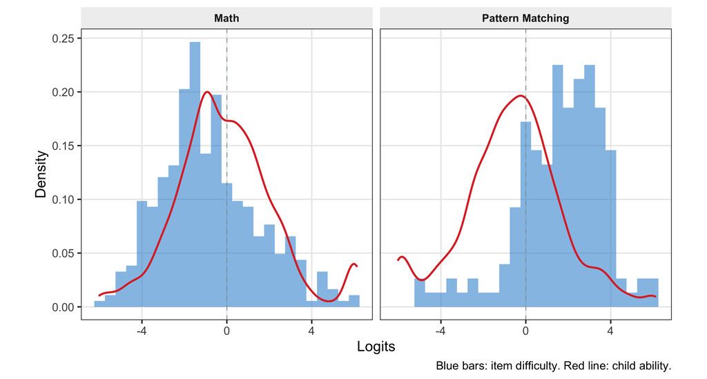

Figure 9: Item-bank difficulty (bars) against child ability (line), Math vs Pattern Matching. Math has 65 items below −3 logits and no child without an easy item; Pattern Matching has 12 items below −1 for a population with a quarter of children below −2.2.

```r
ggplot(ba |> filter(Task %in% c("Math", "Pattern Matching")) |>
         mutate(Task = ord_task(Task) |> droplevels())) +
  geom_histogram(data = \(d) filter(d, what == "item difficulty"),
                 aes(value, after_stat(density)), binwidth = .5,
                 fill = BLUE, alpha = .55) +
  geom_density(data = \(d) filter(d, what == "child ability"), aes(value),
               colour = RED, linewidth = .8) +
  geom_vline(xintercept = 0, colour = GREY, linewidth = .3, linetype = "dashed") +
  facet_wrap(~ Task) +
  labs(x = "Logits", y = "Density",
       caption = "Blue bars: item difficulty. Red line: child ability.") +
  theme(aspect.ratio = 1)
```

Figure 10 below shows the same picture for every task at once, with Math and Pattern Matching at opposite ends of the ordering. The same comparison as numbers — bank size, where the items sit, and how many of them are actually easy enough for the children taking the task:

```r
read_csv(file.path(PROJ, "processed_data/44_bank_ability.csv"), show_col_types = FALSE) |>
  mutate(Task = unname(pretty_task[task_id])) |>
  filter(Task %in% c("Math", "Pattern Matching"), what == "item difficulty") |>
  group_by(Task) |>
  summarise(`Bank size` = n(), `Median b` = round(median(value), 2),
            `Min b` = round(min(value), 2), `Items < −1` = sum(value < -1),
            `Items < −2` = sum(value < -2), `Items < −3` = sum(value < -3),
            .groups = "drop") |> arrange(ord_task(Task)) |>
  kable(align = "lrrrrrr")
```

| Task | Bank size | Median b | Min b | Items < −1 | Items < −2 | Items < −3 |
| --- | --- | --- | --- | --- | --- | --- |
| Math | 365 | -1.22 | -6.04 | 193 | 109 | 65 |
| Pattern Matching | 151 | 1.97 | -5.12 | 12 | 9 | 6 |

Table 8: Item-bank size and difficulty against the children taking each task.

So if math is hard at age 5 the cause is something other than bank floor. Untested candidates: the $\theta = 0$ start costing the first 2–3 trials, the early-block item mix, or a real construct floor. At 54% against ~68%, age 5 is on the *below-optimal* side — making it easier would **gain** information.

## For reference: every other task’s bank

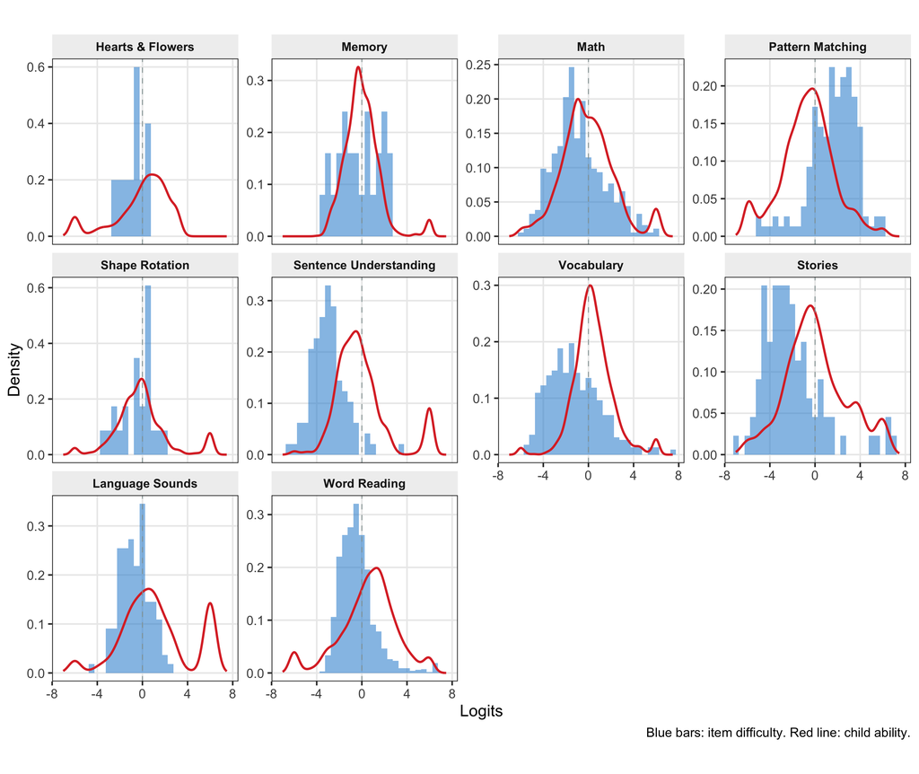

```r
offsets <- ba |> group_by(Task, what) |> summarise(m = median(value), .groups = "drop") |>
  pivot_wider(names_from = what, values_from = m) |>
  mutate(offset = `item difficulty` - `child ability`) |> arrange(ord_task(Task))

ba2 <- ba |> mutate(Task = ord_task(Task) |> droplevels())

ggplot() +
  geom_histogram(data = ba2 |> filter(what == "item difficulty"),
                 aes(value, after_stat(density)), binwidth = .5, fill = BLUE, alpha = .55) +
  geom_density(data = ba2 |> filter(what == "child ability"), aes(value),
               colour = RED, linewidth = .8) +
  geom_vline(xintercept = 0, colour = GREY, linewidth = .3, linetype = "dashed") +
  facet_wrap(~ Task, ncol = 4, scales = "free_y") +
  labs(x = "Logits", y = "Density",
       caption = "Blue bars: item difficulty. Red line: child ability.") +
  theme(aspect.ratio = 1)
```

And the summary statistic behind those panels: the offset between where each bank sits and where its children sit. A large positive number means the bank is aimed above the population.

```r
offsets |> filter(!is.na(`child ability`)) |>
  transmute(Task, `Median item b` = round(`item difficulty`, 2),
            `Median child θ` = round(`child ability`, 2),
            `Offset (item − child)` = round(offset, 2)) |> kable(align = "lrrr")
```

| Task | Median item b | Median child θ | Offset (item − child) |
| --- | --- | --- | --- |
| Hearts & Flowers | -0.42 | 0.48 | -0.90 |
| Memory | -0.29 | -0.14 | -0.15 |
| Math | -1.22 | -0.23 | -0.99 |
| Pattern Matching | 1.97 | -0.57 | 2.54 |
| Shape Rotation | -0.13 | -0.25 | 0.12 |
| Sentence Understanding | -3.09 | -0.48 | -2.61 |
| Vocabulary | -1.52 | 0.30 | -1.82 |
| Stories | -2.61 | -0.23 | -2.38 |
| Language Sounds | -0.66 | 0.74 | -1.39 |
| Word Reading | -0.61 | 0.80 | -1.41 |

Table 9: Offset between where each bank sits and where its children sit.

# Are CATs specifically vulnerable?

A rapid guess is usually wrong; the CAT cannot tell it from a genuine failure, lowers $\hat\theta$, and serves an easier next item (Wise & Kingsbury 2016). Fixed forms cannot do this.

```r
nxt <- rt_tr |> filter(is_adaptive) |> arrange(run_id, trial_number) |>
  group_by(run_id) |>
  mutate(b_next = lead(b), tn_next = lead(trial_number), pos_pct = trial_number/n()) |>
  ungroup() |> filter(!is.na(b_next), tn_next == trial_number + 1) |>
  mutate(db = b_next - b,
         cat_ = factor(case_when(correct == 1 & rapid == 1 ~ "correct (rapid)",
                                 correct == 1 ~ "correct (solution)",
                                 rapid == 1 ~ "incorrect (rapid guess)",
                                 TRUE ~ "incorrect (solution)"),
                       levels = c("incorrect (solution)","incorrect (rapid guess)",
                                  "correct (solution)","correct (rapid)")))

nxt |> group_by(`Trial t` = cat_) |>
  summarise(N = n(), `Δ next item difficulty (logits)` = mean(db),
            `Mean position in run` = mean(pos_pct), .groups = "drop") |>
  mutate(across(where(is.numeric), \(x) round(x, 3))) |> kable(align = "lrrr")
```

Change in the difficulty of the next item served, by what happened on the current trial. Adaptive runs only.

| Trial t | N | Δ next item difficulty (logits) | Mean position in run |
| --- | --- | --- | --- |
| incorrect (solution) | 93096 | -0.941 | 0.518 |
| incorrect (rapid guess) | 2992 | -0.179 | 0.614 |
| correct (solution) | 282114 | 0.330 | 0.505 |
| correct (rapid) | 2341 | 0.048 | 0.633 |

```r
read_csv(file.path(PROJ, "processed_data/38_shift_by_stratum.csv"), show_col_types = FALSE) |>
  transmute(Mode = mode, Stratum = stratum, Runs = n_runs,
            `Median rapid` = sprintf("%.1f%%", median_rapid_pct),
            `Median abs. θ shift` = sprintf("%.3f", median_abs_shift),
            `90th pct` = sprintf("%.3f", p90_abs_shift)) |> kable(align = "llrrrr")
```

Effort-moderated ability shift — the gap between theta estimated from all trials and from solution-behaviour trials only, by how much rapid guessing the run contains.

| Mode | Stratum | Runs | Median rapid | Median abs. θ shift | 90th pct |
| --- | --- | --- | --- | --- | --- |
| CAT | <5% | 689 | 2.2% | 0.071 | 0.254 |
| CAT | 5-10% | 171 | 7.0% | 0.095 | 0.412 |
| CAT | 10-20% | 138 | 14.1% | 0.132 | 0.716 |
| CAT | >20% | 108 | 29.2% | 0.208 | 1.127 |
| non-adaptive | <5% | 423 | 1.7% | 0.053 | 0.229 |
| non-adaptive | 5-10% | 81 | 7.3% | 0.106 | 0.505 |
| non-adaptive | 10-20% | 51 | 13.3% | 0.114 | 0.493 |
| non-adaptive | >20% | 33 | 32.4% | 0.358 | 1.800 |

**ImportantThe honest read**

**The loop is real but small.** Median rapid guessing in CAT runs is 3.4% and the resulting $\theta$ displacement is 0.07–0.09 logits — a child at the 4-choice optimum served items at p = .667 instead of .683.

It bites only where disengagement concentrates: in runs with **>20% rapid guessing** the median displacement is **0.21 logits**, 90th percentile **1.13**. And CAT is **not** worse than non-adaptive — the opposite of the Wise prediction. Our rates are too low for the loop to compound.

So the case for battery-wide effort screening rests on **item calibration** (easy items biased 0.79 logits in Wise & DeMars) and on **young children**, not on a scoring crisis.

# When children fall behind

Findings about *within-session* dynamics that bear directly on the design.

## Wrong-answer streaks

**One grouping matters here, and it is not adaptivity.** The manuscript (`ms.qmd:208`) documents a discontinue rule that ends a task after consecutive incorrect answers — three in early Colombia piloting, six thereafter — and separately states that CAT variants stop on a **time** limit instead (`ms.qmd:680`, 4–6 minutes). ROAR tasks have no rule at all. So runs divide into those a consecutive-error rule can truncate and those it cannot:

- **Truncated** — non-adaptive core variants.
- **Not truncated** — every CAT variant and all three ROAR tasks.

That distinction has to be respected because a truncated run cannot exhibit a long streak: the task ends first.

**This section reports the not-truncated group only** — every CAT variant plus the three ROAR tasks. Their streak counts are what the data look like when nothing cuts a run short, and they are also the runs the question is about: this is a CAT UX problem, and the same principles apply.

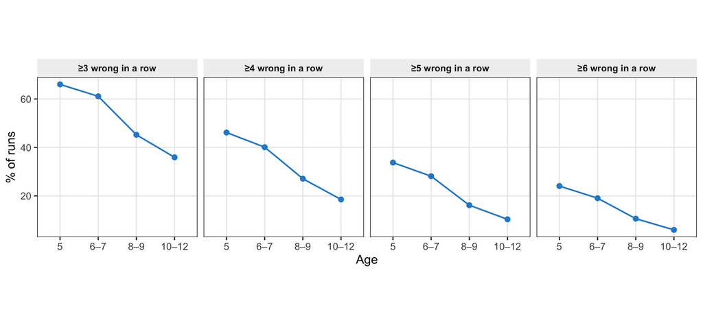

Figure 11: Share of runs containing an error streak of at least a given length, by age, for the runs no consecutive-error rule can truncate. Each panel is one threshold.

```r
sd_ <- read_csv(file.path(PROJ, "processed_data/52_streak_by_group.csv"),
                show_col_types = FALSE) |>
  filter(Group == "No error limit (CAT + ROAR)") |>
  mutate(Age = factor(Age, levels = c("5", "6–7", "8–9", "10–12")))

ggplot(sd_, aes(Age, pct, group = Group)) +
  geom_line(linewidth = .7, colour = BLUE) + geom_point(size = 2, colour = BLUE) +
  facet_wrap(~ threshold, nrow = 1) +
  scale_y_continuous("% of runs") +
  labs(x = "Age") +
  theme(aspect.ratio = 1, legend.position = "none")
```

Streaks fall steadily with age. **ROAR, with no rule at all, tops out at 3.5–3.9% of runs reaching eight consecutive errors** (Word Reading 3.5%, Language Sounds 3.9%, Sentence Reading 1.4%). Pattern Matching CAT reaches **42.5%**. So its streaks are not what happens when a rule is missing — they are an order of magnitude beyond that.

### What happens after a streak — and whether it is the streak

Conditioning on “k preceding errors” invites two confounds the raw series cannot separate. **Position**: streaks fall late in runs, and behavior worsens with position regardless. **Difficulty**: streaks happen when items have been too hard, so “after a streak” is also “after hard items.” Both are now handled (scripts 77–78):

```r
read_csv(file.path(PROJ, "processed_data/77_streak_position.csv"),
         show_col_types = FALSE) |>
  transmute(Outcome = outcome,
            `β, no position` = sprintf("%+.3f", beta_no_position),
            `β, position controlled` = sprintf("%+.3f", beta_position),
            `Attenuation` = sprintf("%.0f%%", attenuation_pct),
            p = fmt_p(p_position)) |>
  kable(align = "lrrrr")
```

| Outcome | β, no position | β, position controlled | Attenuation | p |
| --- | --- | --- | --- | --- |
| rapid (NT10) | +0.014 | +0.014 | 5% | <.001 |
| rapid (task-constant threshold) | +0.015 | +0.014 | 7% | <.001 |
| RT z (within run) | -0.178 | -0.156 | 13% | <.001 |
| residual accuracy | -0.003 | -0.002 | 49% | 0.677 |

Table 10: Effect of a preceding streak of ≥3 wrong answers, with and without position control (not-truncated runs; run FE, current-trial difficulty held; script 77). The rapid-guessing and RT effects survive nearly intact; residual accuracy does not survive within-run identification even before position enters.

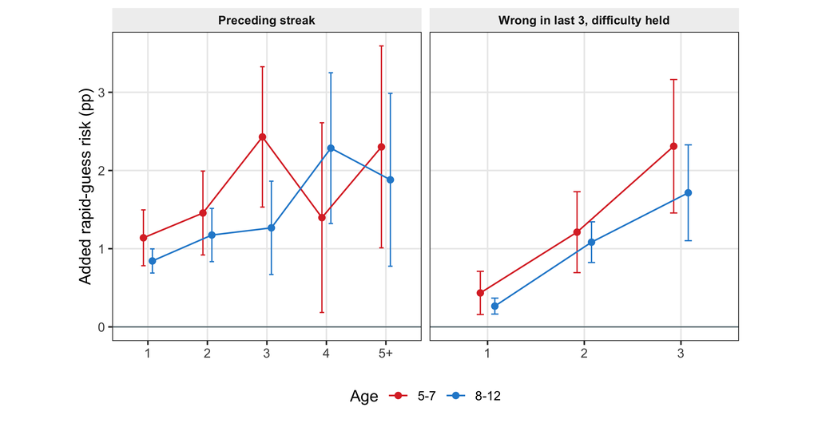

Figure 12: Left: added rapid-guess risk by preceding consecutive wrong answers, position-controlled, by age band (tasks pooled; 95% CIs). Right: the luck-matched dose — added risk per wrong answer among the previous three trials, holding those trials’ difficulty fixed, which makes their outcomes as-good-as-random. Both effects hold in both bands. Scripts 78/83.

```r
sa <- read_csv(file.path(PROJ, "processed_data/83_streak_by_age.csv"),
               show_col_types = FALSE) |>
  mutate(k = factor(k, levels = c("1","2","3","4","5+")), what = "Preceding streak")
la <- read_csv(file.path(PROJ, "processed_data/83_luck_by_age.csv"),
               show_col_types = FALSE) |>
  mutate(k = factor(k, levels = c("1","2","3")),
         what = "Wrong in last 3, difficulty held")
bind_rows(sa, la) |>
  ggplot(aes(k, 100*beta, colour = age_band, group = age_band)) +
  geom_hline(yintercept = 0, colour = DARK, linewidth = .4) +
  geom_errorbar(aes(ymin = 100*(beta-1.96*se), ymax = 100*(beta+1.96*se)),
                width = .15, linewidth = .45, position = position_dodge(.3)) +
  geom_line(linewidth = .55, position = position_dodge(.3)) +
  geom_point(size = 1.9, position = position_dodge(.3)) +
  facet_wrap(~ what, scales = "free_x") +
  scale_colour_manual(values = c(`5-7` = RED, `8-12` = BLUE)) +
  labs(x = NULL, y = "Added rapid-guess risk (pp)", colour = "Age") +
  theme(aspect.ratio = 1, legend.position = "bottom")
```

**The lesson.** The streak effect is real, not an artifact of where streaks fall in a run (5% attenuation under position control) — and the right panel shows **failure itself does damage**: holding the difficulty of the previous three trials fixed, each additional failure among them adds +0.3 / +1.1 / +2.0pp of rapid-guess risk. This is the premise a rescue rule needs, and it is the closest to causal evidence pilot data can produce.

One caution the pooled numbers hide: per task, the streak dose is clean in Math, Vocabulary and Word Reading but **flat in Pattern Matching** — the task whose runs are one long streak. Where consecutive failure is the norm, the *marginal* effect of one more error disappears. A rescue rule aimed at Pattern Matching treats a symptom the bank causes; it earns its keep on tasks where failure is still an event.

### Error timing along a streak

The natural way to add $\Delta_{\text{err}}$ here breaks. It contrasts response times on wrong versus right answers *within* a set of trials, and conditioning on a long preceding streak selects a set that is almost entirely wrong answers — so the contrast rests on a handful of correct responses, which are disproportionately lucky guesses and therefore fast. The fix is to stop taking the ratio and track the two series separately, each standardized within the child’s own run (script 55).

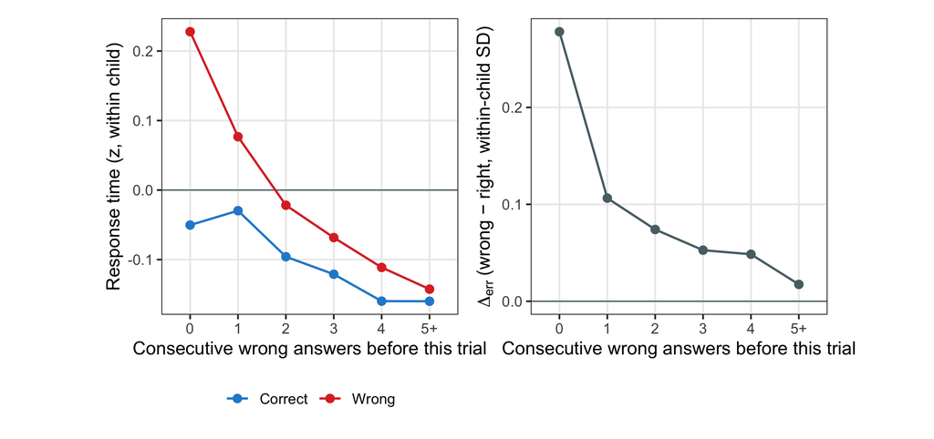

Figure 13: Response time on wrong and on right answers separately, against the number of immediately preceding errors, standardized within each child’s own run. Both classes speed up as failure accumulates, but wrong answers speed up more than three times as fast, so the gap between them — the engaged-error signature — closes. Not-truncated runs only (CAT plus ROAR).

```r
dec <- read_csv(file.path(PROJ, "processed_data/55_errtiming_decomposed.csv"),
                show_col_types = FALSE) |>
  mutate(k = factor(k, levels = c("0","1","2","3","4","5+")))

p_dec <- ggplot(dec, aes(k, rt_z, colour = Outcome, group = Outcome)) +
  geom_hline(yintercept = 0, colour = DARK, linewidth = .4) +
  geom_ribbon(aes(ymin = rt_z - 1.96*se, ymax = rt_z + 1.96*se, fill = Outcome),
              alpha = .15, colour = NA) +
  geom_line(linewidth = .7) + geom_point(size = 2.2) +
  scale_colour_manual(values = c(Wrong = RED, Correct = BLUE), name = NULL) +
  scale_fill_manual(values = c(Wrong = RED, Correct = BLUE), guide = "none") +
  labs(x = "Consecutive wrong answers before this trial",
       y = "Response time (z, within child)") +
  theme(aspect.ratio = 1, legend.position = "bottom")

p_gap <- ggplot(distinct(dec, k, delta_err_z), aes(k, delta_err_z, group = 1)) +
  geom_hline(yintercept = 0, colour = DARK, linewidth = .4) +
  geom_line(linewidth = .7, colour = DARK) + geom_point(size = 2.2, colour = DARK) +
  labs(x = "Consecutive wrong answers before this trial",
       y = expression(Delta[err]~"(wrong − right, within-child SD)")) +
  theme(aspect.ratio = 1)

patchwork::wrap_plots(p_dec, p_gap, nrow = 1)
```

**The lesson.** Response times on wrong answers fall by **0.37 within-child SD** across the streak range while correct answers fall by only **0.11**, so $\Delta_{\text{err}}$ collapses from **0.278 to 0.017** — the engaged-error signature all but disappears by the fifth consecutive failure. A trial-level model holding item easiness and task fixed gives the same result: the gap starts at 0.110 SD with no preceding errors and every interaction with streak length is negative (−0.042 to −0.060, all *p* < .001, n = 376,653). Children are not working harder and failing — they are disengaging, and it shows up first and most strongly in how fast their wrong answers arrive.

## Would a rescue rule help, and what would it cost?

The obvious intervention: **once a child gets $k$ wrong in a row, hand them one deliberately easy item**, then resume normal selection. Two questions — does it break the scoring, and what does it cost in precision?

### It does not break the scoring

An IRT likelihood does not care *why* an item was chosen, only which item was chosen and whether the child got it right. Because the rule depends only on responses already observed, the selection is ignorable in the technical sense (Mislevy & Wu 1996) and $\hat\theta$ stays consistent. A CAT is already doing exactly this — every item after the first is chosen based on prior responses. A rescue rule is the same kind of rule with a different trigger.

**What it does change is precision.** An easy item carries less information than an optimally-targeted one, so the run ends with a slightly wider SE. That is the quantity worth pricing.

### What each trigger would buy, and what it would cost

A rescue rule has **two dials**, and they are priced separately below. The first is the **trigger** — how many consecutive wrong answers before the rule fires. The second is **how easy to make the rescue item we serve the child** — stated as the probability the child answers it correctly, so an item at p = .85 is one this child should get right 85% of the time, and p = .95 is a near-guaranteed win. Easier means a more certain break for the child and less measurement information from that trial; the first table below varies the trigger with the item held at p = .85, and the second holds the trigger fixed and varies the item.

To put a benefit against the trigger’s cost, simulate it: keep every run’s observed correct/incorrect sequence, walk it with a counter that **resets to zero whenever a rescue fires**, and re-score each trial at the outcome level its new preceding-error count implies (script 60). Two assumptions — a rescue fully restores the no-streak state (optimistic, so the reductions are **upper bounds**), and later accuracy is unchanged (conservative).

```r
read_csv(file.path(PROJ, "processed_data/60_counterfactual.csv"),
         show_col_types = FALSE) |>
  filter(is.na(k) | k %in% 1:5) |>
  transmute(Trigger = if_else(is.na(k), "no rule (observed)", as.character(k)),
            `Rescues per run` = sprintf("%.2f", rescues_per_run),
            `Information cost` = sprintf("%.2f%%", info_cost_pct),
            `Rapid guessing` = sprintf("%.2f%%", 100*p_rapid_cf),
            `Reduction` = if_else(is.na(k), "—", sprintf("%.0f%%", pct_drop))) |>
  kable(align = "lrrrr")
```

| Trigger | Rescues per run | Information cost | Rapid guessing | Reduction |
| --- | --- | --- | --- | --- |
| no rule (observed) | 0.00 | 0.00% | 1.44% | — |
| 1 | 15.00 | 3.98% | 0.81% | 43% |
| 2 | 3.92 | 1.04% | 1.14% | 21% |
| 3 | 1.49 | 0.39% | 1.29% | 11% |
| 4 | 0.68 | 0.18% | 1.36% | 5% |
| 5 | 0.36 | 0.10% | 1.40% | 3% |

Table 11: Battery-wide outcome if a rescue at each trigger reset the child to the no-streak state (script 60). Reductions are upper bounds — the substituted baseline averages over mostly never-disengaged children.

Now the second dial. With the trigger held at four consecutive errors, the table below varies **the easiness of the rescue item itself** — each column is one choice of how likely the child is to get the rescue item right — and reports what that choice costs in the task’s total information over a whole run:

```r
read_csv(file.path(PROJ, "processed_data/56_rescue_task_loss.csv"), show_col_types = FALSE) |>
  filter(trigger == 4) |>
  transmute(Task, Mode, Items = n_items,
            `Initiations per run` = sprintf("%.2f", per_run),
            p_rescue = sprintf("p = %.2f", p_rescue),
            pct = pct_task_info) |>
  pivot_wider(names_from = p_rescue, values_from = pct) |>
  mutate(across(starts_with("p ="), \(x) sprintf("%.2f%%", x))) |>
  arrange(ord_task(Task), desc(Mode)) |>
  kable(align = "llrrrrrr")
```

| Task | Mode | Items | Initiations per run | p = 0.80 | p = 0.85 | p = 0.90 | p = 0.95 |
| --- | --- | --- | --- | --- | --- | --- | --- |
| Math | non-adaptive | 90 | 0.88 | 0.13% | 0.26% | 0.45% | 0.69% |
| Math | CAT | 40 | 0.38 | 0.12% | 0.26% | 0.44% | 0.67% |
| Pattern Matching | non-adaptive | 22 | 1.36 | 0.81% | 1.67% | 2.85% | 4.36% |
| Pattern Matching | CAT | 31 | 2.21 | 0.93% | 1.92% | 3.28% | 5.02% |
| Shape Rotation | non-adaptive | 67 | 0.41 | 0.00% | 0.03% | 0.13% | 0.32% |
| Shape Rotation | CAT | 27 | 0.18 | 0.00% | 0.03% | 0.14% | 0.36% |
| Sentence Understanding | non-adaptive | 86 | 0.19 | 0.03% | 0.06% | 0.10% | 0.15% |
| Sentence Understanding | CAT | 40 | 0.14 | 0.05% | 0.10% | 0.17% | 0.25% |
| Vocabulary | non-adaptive | 122 | 0.50 | 0.05% | 0.11% | 0.19% | 0.29% |
| Vocabulary | CAT | 46 | 0.36 | 0.10% | 0.21% | 0.36% | 0.55% |
| Language Sounds | non-adaptive | 20 | 0.39 | 0.13% | 0.38% | 0.76% | 1.28% |
| Word Reading | non-adaptive | 120 | 0.88 | 0.00% | 0.03% | 0.16% | 0.39% |

Table 12: Share of the whole task’s information given up over a run at trigger k=4, by how easy the rescue item is made — columns are the rescue item’s expected accuracy for the child (script 56).

**It is cheap almost everywhere, and the exception is informative.** At the k = 4 trigger with a rescue item at p = .85, Math CAT gives up **0.26%** of its information over a whole run, Vocabulary 0.21%, Sentence Understanding 0.10%, Word Reading 0.03%. **Pattern Matching is the exception at 1.92%**, and only because the rule fires 2.21 times per run there against 0.38 on Math — the cost scales with how often a child is failing, so the task that would pay most is precisely the one where something is already wrong. On Pattern Matching a scored rescue is not available anyway (easy items are the scarce resource); a deliberately trivial **unscored** item, or an unscored item with the clock extended ~5 seconds to pay for it, delivers the break without consuming the bank (script 53: the clock-extended design costs 0.0% of information and ~11 seconds on Pattern Matching; battery-wide, ~16 seconds on a ~60-minute wave).

**ImportantThe trigger is a dial, not a derivation**

**WarningThe ceiling matters more than the choice between them**

Resetting after *every single error* — 15 rescues per run, an absurd design included only as a bound — reduces rapid guessing by just **43%**. Most rapid guessing does not follow a streak at all; it happens at preceding-error level zero.

**So a rescue rule cannot fix disengagement, at any trigger. It trims a minority of it.** The larger lever remains targeting and the item bank, which is where the other 57% lives. A rescue rule is worth adding because it is nearly free, not because it solves the problem.

# Error timing: what the contrast actually measures

The errors-slower-than-correct contrast needs its item-difficulty confound removed before it means anything — harder items are both slower and more often wrong, so the raw task-level contrast partly measures which items landed in each pile (scripts 63–65, 72–73; the mental-rotation paper’s own residual control and item fixed effects agree at r = .96 across tasks). Once removed, what remains tracks the **served-difficulty regime**, not engagement:

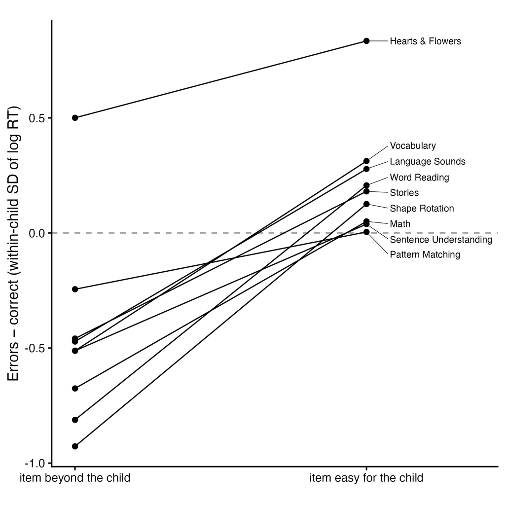

The gap’s *level* is therefore not an engagement measure and is not used as one anywhere in this document. Its within-run *change* remains informative — the streak collapse in Section 12 — with the caveat that a change-based reading assumes the child’s speed-accuracy settings are otherwise stable within the run, which the speeding-after-failure result itself qualifies.

# Proposed experiment

Two tasks, chosen to differ in exactly the way that matters:

- **Pattern Matching CAT** — the mistargeted case, realizing 39% against a 68% optimum.
- **Math CAT** — the well-targeted control, realizing 72% against the same 68% optimum, with a bank that already reaches −6 logits.

Within each, assign children at random to a **target expected accuracy from 50% to 95% in 5% increments** (10 levels). A sweep rather than three arms, because the question is no longer *whether* easiness helps but **where the two objectives cross** — and the observational data can bound that crossing only from below.

|  | Pattern Matching CAT | Math CAT |
| --- | --- | --- |
| Realized today | 39% | 72% |
| Own optimum | 68% | 68% |
| Sweep range | 50–95% in 5% steps | 50–95% in 5% steps |
| Bank supports it? | **To 80%, ages 9+; full range needs extension** | Yes |
| Expected direction | Large gains at every level | Cost above ~75% |

Running both is what separates “easier helps because the task was broken” from “easier helps generally.” If the Math curve is flat and the Pattern Matching curve rises steeply, the problem was targeting. If both rise, easiness is doing something beyond fixing a bad bank.

The section is organized the way the decision actually presents itself: **the study we can run today**, **the study we would ideally run**, and **what it takes to get from one to the other**.

## The study we can run today

Extending the feasibility computation to every task running a LEVANTE jsCat CAT (script 86 — Word Reading is excluded because it runs ROAR’s own CAT framework, Same & Different pending rescoring), **three tasks support the full sweep with today’s banks**, and two of them support it from age 5:

```r
read_csv(file.path(PROJ, "processed_data/86_design_options_all.csv"),
         show_col_types = FALSE) |>
  filter(feasible) |>
  group_by(task_id, floor) |>
  summarise(children = first(children), max_ceiling = max(ceiling),
            .groups = "drop") |>
  mutate(Task = unname(pretty_task[task_id])) |>
  select(Task, floor, children, max_ceiling) |>
  pivot_wider(names_from = floor, values_from = c(children, max_ceiling)) |>
  transmute(Task,
            `Ages 5+` = sprintf("%.0f%% (n=%d)", 100*max_ceiling_5, children_5),
            `7+` = sprintf("%.0f%% (n=%d)", 100*max_ceiling_7, children_7),
            `9+` = sprintf("%.0f%% (n=%d)", 100*max_ceiling_9, children_9),
            `11+` = sprintf("%.0f%% (n=%d)", 100*max_ceiling_11, children_11)) |>
  arrange(ord_task(Task)) |> kable(align = "lrrrr")
```

| Task | Ages 5+ | 7+ | 9+ | 11+ |
| --- | --- | --- | --- | --- |
| Math | 90% (n=1172) | 95% (n=996) | 95% (n=636) | 95% (n=207) |
| Pattern Matching | 50% (n=662) | 50% (n=540) | 70% (n=349) | 80% (n=116) |
| Shape Rotation | 70% (n=626) | 75% (n=484) | 80% (n=293) | 80% (n=110) |
| Sentence Understanding | 95% (n=856) | 95% (n=704) | 95% (n=448) | 95% (n=150) |
| Vocabulary | 95% (n=942) | 95% (n=745) | 95% (n=452) | 95% (n=150) |

Table 13: Maximum sweep ceiling each bank supports (≥90% of children with ≥5 usable items at every target from the format’s floor up), by task and age floor; adaptive runs, ages 5–12 (script 86). Shape Rotation is 2-choice, so its sweep starts at 55%.

The design this supports, with no bank work at all:

- **Vocabulary CAT and Sentence Understanding CAT: the full 50–95% sweep from age 5** (942 and 856 children). Both are 4-choice tasks with the same 68% optimum as Pattern Matching, both currently run *friendlier* than optimal — so their low arms test the too-hard side and their high arms locate the turnover, across the full range, including the youngest children.
- **Math CAT: the full sweep at ages 7+** (996 children; from age 5 it supports a sweep to 90%).
- **Pattern Matching CAT: a truncated 50–80% sweep, ages 9+** (349 children, 87% with full item support; the remainder handled by a prespecified **eligibility screen** — each child is randomized only among targets the bank can deliver for them; seven 5-point arms ≈ 50 per arm, four arms 55/65/75/80 ≈ 87).
- **Shape Rotation CAT** is the partial candidate if a 2-choice format arm is wanted: 55–75% at ages 7+, to 80% at 9+.

**What this study answers.** With three full-range tasks spanning language, math, and (partially) spatial formats, today’s design can do more than test the 75–80% recommendation: it can **locate where the engagement benefit turns over** in well-aimed tasks across constructs — the general principle — while the Pattern Matching arm tests the recommendation band in the mistargeted case. **What it still cannot answer**: where the benefit turns over in the *mistargeted* task itself, and anything about children under 9 on Pattern Matching — the children the mistargeting hits hardest.

### Why these are the bounds

Older children sit higher on the ability scale, so the items a given target requires are less extreme. Inverting the model gives the difficulty each child needs for each target — $b = \theta - \mathrm{logit}\!\left(\frac{p-g}{1-g}\right)$ — and the bank either holds enough such items or it does not. A sweep arm serves many trials and cannot reuse one item, so the criterion below is **at least five** usable items, not one.

```r
read_csv(file.path(PROJ, "processed_data/59_sweep_feasibility.csv"),
         show_col_types = FALSE) |>
  mutate(Task = unname(pretty_task[task_id])) |>
  select(Task, band, target, pct_ge5) |>
  pivot_wider(names_from = target, values_from = pct_ge5,
              names_prefix = "p=") |>
  mutate(across(starts_with("p="), \(x) sprintf("%.0f%%", x))) |>
  arrange(ord_task(Task), as.numeric(sub("[^0-9].*$", "", band))) |>
  kable(align = "llrrrrrrrrrr")
```

| Task | band | p=0.5 | p=0.55 | p=0.6 | p=0.65 | p=0.7 | p=0.75 | p=0.8 | p=0.85 | p=0.9 | p=0.95 |
| --- | --- | --- | --- | --- | --- | --- | --- | --- | --- | --- | --- |
| Math | 5–6 | 100% | 95% | 93% | 90% | 89% | 86% | 81% | 74% | 65% | 46% |
| Math | 7–8 | 100% | 100% | 99% | 99% | 99% | 98% | 97% | 96% | 94% | 85% |
| Math | 9–10 | 100% | 100% | 100% | 100% | 100% | 100% | 100% | 100% | 99% | 97% |
| Math | 11–12 | 100% | 100% | 100% | 100% | 100% | 100% | 100% | 100% | 100% | 99% |
| Pattern Matching | 5–6 | 80% | 78% | 74% | 70% | 66% | 63% | 61% | 52% | 42% | 31% |
| Pattern Matching | 7–8 | 86% | 82% | 80% | 79% | 76% | 73% | 70% | 62% | 54% | 39% |
| Pattern Matching | 9–10 | 95% | 92% | 91% | 90% | 88% | 86% | 85% | 78% | 70% | 57% |
| Pattern Matching | 11–12 | 98% | 97% | 97% | 97% | 97% | 95% | 93% | 84% | 76% | 60% |

The same evidence as a decision table — every combination of age floor and sweep ceiling, with the binding case always the hardest target for the least able children in the range:

```r
read_csv(file.path(PROJ, "processed_data/61_design_options.csv"),
         show_col_types = FALSE) |>
  mutate(Task = unname(pretty_task[task_id])) |>
  arrange(ord_task(Task), age_floor, p_max) |>
  transmute(Task, `Age floor` = paste0(age_floor, "+"),
            `Sweep to` = sprintf("%.0f%%", 100*p_max),
            Children = n_kids,
            `Hardest item needed` = sprintf("%.1f", b_needed),
            `Items that deep` = n_have,
            `% children covered` = sprintf("%.0f%%", pct_ok),
            Feasible = if_else(feasible, "yes", "—")) |>
  kable(align = "llrrrrrl")
```

| Task | Age floor | Sweep to | Children | Hardest item needed | Items that deep | % children covered | Feasible |
| --- | --- | --- | --- | --- | --- | --- | --- |
| Math | 5+ | 80% | 1172 | -4.1 | 29 | 96% | yes |
| Math | 5+ | 90% | 1172 | -5.0 | 11 | 93% | yes |
| Math | 5+ | 95% | 1172 | -5.7 | 2 | 86% | — |
| Math | 7+ | 80% | 996 | -3.3 | 65 | 98% | yes |
| Math | 7+ | 90% | 996 | -4.1 | 29 | 97% | yes |
| Math | 7+ | 95% | 996 | -4.9 | 11 | 93% | yes |
| Math | 9+ | 80% | 636 | -2.6 | 92 | 100% | yes |
| Math | 9+ | 90% | 636 | -3.4 | 53 | 99% | yes |
| Math | 9+ | 95% | 636 | -4.2 | 25 | 98% | yes |
| Math | 11+ | 80% | 207 | -2.2 | 114 | 100% | yes |
| Math | 11+ | 90% | 207 | -3.0 | 73 | 100% | yes |
| Math | 11+ | 95% | 207 | -3.8 | 39 | 99% | yes |
| Pattern Matching | 5+ | 80% | 662 | -5.5 | 0 | 77% | — |
| Pattern Matching | 5+ | 90% | 662 | -6.4 | 0 | 61% | — |
| Pattern Matching | 5+ | 95% | 662 | -7.1 | 0 | 48% | — |
| Pattern Matching | 7+ | 80% | 540 | -5.3 | 1 | 81% | — |
| Pattern Matching | 7+ | 90% | 540 | -6.1 | 0 | 66% | — |
| Pattern Matching | 7+ | 95% | 540 | -6.9 | 0 | 51% | — |
| Pattern Matching | 9+ | 80% | 349 | -4.3 | 3 | 87% | — |
| Pattern Matching | 9+ | 90% | 349 | -5.1 | 1 | 72% | — |
| Pattern Matching | 9+ | 95% | 349 | -5.9 | 0 | 58% | — |
| Pattern Matching | 11+ | 80% | 116 | -3.7 | 5 | 93% | yes |
| Pattern Matching | 11+ | 90% | 116 | -4.6 | 3 | 76% | — |
| Pattern Matching | 11+ | 95% | 116 | -5.4 | 1 | 60% | — |

Table 15: Which sweep designs the current banks support. Feasible means at least 90% of children in the age range have at least five usable items at every target in the sweep.

Two dead ends worth recording so nobody re-derives them. Restricting harder — **ages 11+ sweeping to 80%** — does clear the 90% item-coverage bar, but at **116 children** (~12 per arm) it is far too small to power any engagement outcome; passing the item criterion is not the same as being a runnable study, which is why the ages-9+ version with an eligibility screen is the one worth running. And **dropping Pattern Matching entirely** (Math alone) would test whether easier targeting helps in a well-aimed task, but not whether it rescues a badly-aimed one — the question Pattern Matching was chosen to answer.

## The study we would ideally run

The **full 50–95% sweep on both tasks, down to age 5**. Beyond what today’s study delivers, the full version:

- **locates where the engagement benefit turns over** — the region above 80% is where the engagement and information objectives separate most, and it is exactly the region today’s Pattern Matching bank cannot reach at any age;
- **includes the children the problem is about** — mistargeting hits 5–8 year olds hardest (they realize 31–33% correct today), and they are the ones the truncated design must exclude;
- **prices the whole trade-off curve symmetrically** in both tasks, rather than bounding it from below.

## What the full version requires

**The Pattern Matching bank extension: roughly 30–40 new easy items spanning $b \in [-4.5, -1]$**, seeded into fixed-form positions or calibrated online. The arithmetic behind that number: a full 50–95% sweep needs items down to $b \approx -5.9$ at ages 9+ (or $-5.4$ at 11+), where the bank currently holds **zero and one** items; for a 6-year-old at $\theta \approx -2.5$, an 85% target needs items near $b = -3.9$, and the bank holds 9 below −2. The extension turns every row of the decision table feasible at once — and it fixes the status-quo floor problem regardless of the experiment, so it is half the deliverable rather than overhead. It is also precisely what Eggen & Verschoor’s closing paragraph recommends.

**Sequencing**: today’s study should not wait on the extension, and the extension should not be skipped because today’s study ran — each answers what the other cannot.

## Outcomes

1. **Manipulation check** — realized accuracy against target at each level. Eggen & Verschoor’s warning applies: realized rates run below targeted ones, so both must be reported.
2. **Measurement cost** — SE($\theta$) at fixed item count, which the curves in Section 7 predict analytically. The experiment tests whether the prediction holds in children.
3. **Engagement** — primary: **trial-level rapid guessing with run fixed effects**, the specification of Section 8, whose observational β the sweep tests causally. Secondary: the RT–difficulty slope (under randomization its mechanical component is part of the treatment effect) and the decomposed error-timing series. **Rescue-rule arms at k = 3 and k = 4** if slots allow (Section 12).
4. **Self-reported experience** — Smileyometer plus the Again-Again table immediately post-task, counterbalanced for order (Read & Horton report a 0.6-point order effect, so this is not optional), spoken administration for pre-readers. This is the arm of the argument the pilot data cannot speak to at all.
5. **Retention** — return at the next wave. No study has measured this, and LEVANTE’s design is unusually well placed to.

## Power

~1,400 Pattern Matching CAT runs per wave. Ten levels gives ~140 per level, which is ample for realized accuracy and SE($\theta$) (both large by design) and adequate for a 5-point UX rating. For the engagement measures, pool across adjacent levels or fit accuracy as a continuous predictor rather than testing level-by-level.

**Note**

**Age-stratify.** Prespecify 5–7 vs 8–12. The within-child dose-response holds in both bands (Section 8), but base rates differ by an order of magnitude (rapid guessing runs 8–15% in young Word Reading runs and under 1% in most 8–12 cells), so pooled run-level rates are dominated by the young stratum.

# Could the dose-response be an artifact?

Two worries a skeptical reader should have about the result in Section 8, each with a direct test.

**Worry 1: the analysis might be circular.** The predictor — the trial’s expected accuracy — is computed from the child’s *estimated* ability, and that ability is estimated from the very responses whose quality we are predicting. If the estimate is off for a given run, the error contaminates both sides at once, and that shared error could manufacture a relationship where none exists. The test breaks the loop (script 80): estimate each child’s ability from their **odd-numbered trials only**, use that estimate to compute expected accuracy for the **even-numbered trials**, and rerun the analysis on the even trials. Predictor and outcome now come from disjoint halves of the data, so shared estimation error is impossible.

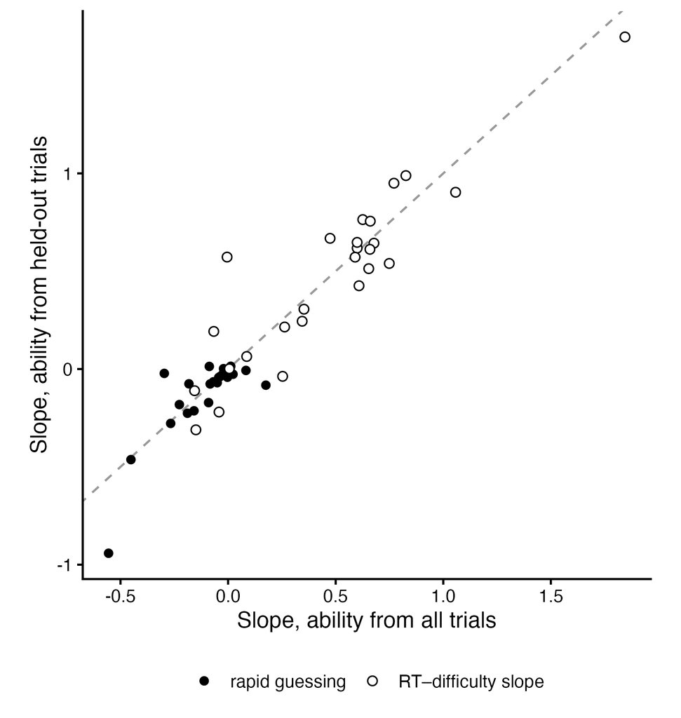

Each point is one task × variant × age cell. Horizontal: the dose-response slope computed the ordinary way (ability estimated from all trials). Vertical: the same slope with ability from held-out odd trials and outcomes from even trials. Points on the dashed identity line mean breaking the circularity changed nothing — and they sit on it (median ratio 1.01 for rapid guessing, filled circles; 0.89 for the RT–difficulty slope, open). Script 80.

**Worry 2: an engaged child might produce the pattern mechanically.** This one applies mainly to the *other* surviving measure. Besides rapid guessing, one more engagement measure came through the project’s screening: the **RT–difficulty slope** — within a run, regress log response time on item difficulty. An engaged child takes longer on harder items (positive slope); a child answering without engaging takes about the same time regardless (flat). That slope also improves as served success rises. But it has a built-in vulnerability: when every item served sits hopelessly far above the child, response time stops varying with difficulty **even for a fully engaged child** — everything is equally impossible — so bad targeting alone could flatten the slope with no disengagement anywhere. The test asks whether that mechanical channel can account for the data (script 79): simulate children who are **engaged by construction** — their response times follow a simple lognormal model that tracks difficulty within the reachable range, with no disengagement process in it — give them each cell’s actual served items and abilities, and run the identical dose-response on the simulated data.

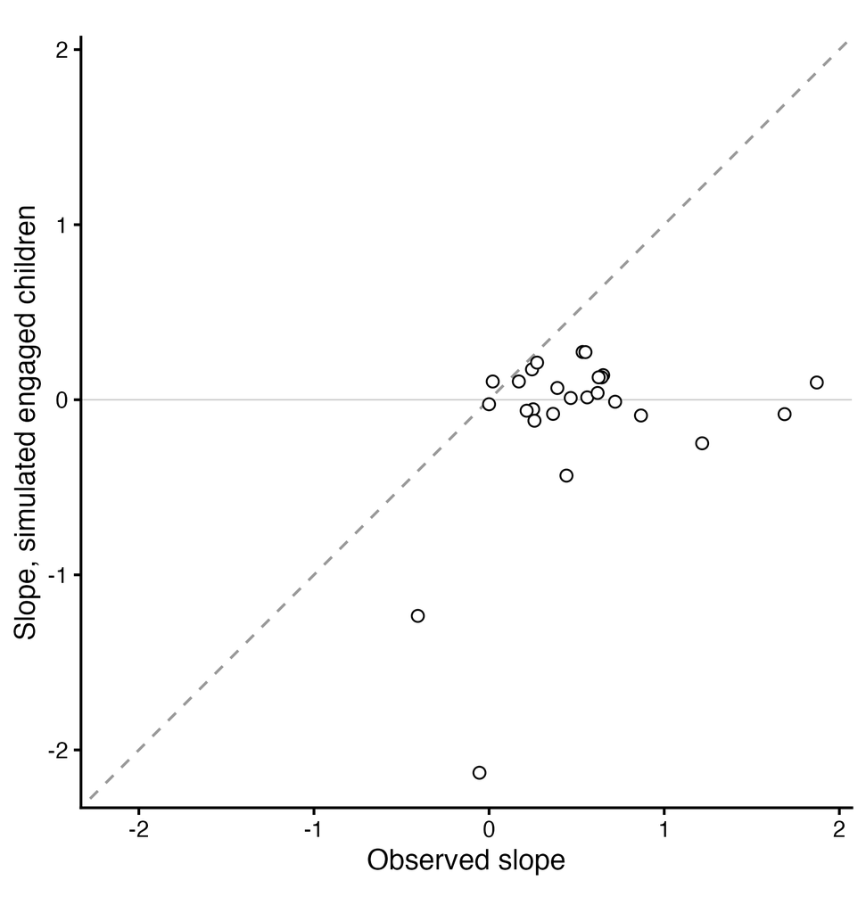

Each point is one task × variant × age cell. Horizontal: the RT–difficulty-slope dose-response estimated in the real data. Vertical: the same estimate in the simulation where every child is engaged by construction. If mistargeting mechanics explained the real result, the points would fall on the dashed identity line; instead the simulated slopes cluster at zero (median 0.01) while the real ones spread positive (median 0.45). The mechanics alone do not produce what the data show. Script 79.

(For rapid guessing itself, the analogous mechanical worry is the threshold — NT10 scales with the item’s typical response time — and the robustness ladder in Section 8 already handles it: the effect survives a threshold that cannot vary by item.)

Between them: the result is not circular, and it is not mistargeting mechanics. The RT–difficulty slope stays the experiment’s *secondary* outcome — under randomization its mechanical component becomes part of the treatment effect — while rapid guessing carries the observational claim.

# Other measures we evaluated

Knowing *why* a measure fails is worth as much as knowing another one works.

- **Rapid guessing at the run level** is floor-limited above age 8 (base rates under 1% in most cells) — which is why this document’s inference moved to the trial level, where the within-child effect is present in both bands (Section 8).
- **Engagement weight π and person misfit (outfit)** are accuracy-model statistics, fit to the same data and the same $\theta$ the expected-accuracy predictor is computed from. π is additionally unidentifiable on runs of this length (a hierarchical Bayesian fit collapses its posterior against a ceiling; script 45). Both peak at the information optimum in curvature analyses — the method confirming itself, and the cleanest evidence they track targeting rather than effort. Not carried.
- **“Taking longer helps” (accuracy on RT quintile)** reverses sign across the battery and is not carried.
- **Errors-slower-than-correct as a level** measures difficulty regime, not engagement (Section 13). Its within-run change is retained.
- **Stories (Theory of Mind)** initially looked like an outlier on error timing (56.4% of runs errors-faster). The cause was ours, not the task’s: Stories mixes 2-, 3- and 4-choice item types (59/20/21% of trials), and a run-level average pools them. LEVANTE’s own pipeline never reduces a Stories run to one number — `recode_tom()` gives every question its own calibrated item, and their exploratory analyses group by question type *and* chance (`tom_subconstructs.qmd`). Holding item identity fixed, Stories sits inside the battery (+0.026 within-child SD, between Word Reading and Vocabulary), and the same pooling artifact is *larger* on five other tasks — four flip sign under the correction (Math, Pattern Matching, Shape Rotation, Sentence Understanding), which is what Section 13 explains. Stories is in every analysis it qualifies for.

# Data-quality flags to carry forward

Each of these is worth raising with the **Data Coordinating Center** — the DCC, headed by Mike, which can authorize changes to measures, scoring, validation and data design.

1. **`adaptive` is FALSE on all Word Reading runs — and that is correct, not a defect.** The column marks whether a run used one of the **LEVANTE core-task CAT variants** built with jsCat. Word Reading is a literacy measure administered through the ROAR framework, with ROAR’s own internal CAT. Analytically, though, Word Reading *does* adapt: every trial carries a running $\theta$ estimate and no two children get the same item sequence, so this document groups it with the adaptive tasks — **our analytic choice, not a correction to their data**. Language Sounds and Sentence Reading are the opposite case and genuinely do not adapt.
2. **Hearts & Flowers item parameters carry an `hf_` prefix the trial data does not**, so the two tables silently join to zero rows. All 10 items exist and are calibrated; stripping the prefix matches them. A naming defect, not a missing calibration.
3. **Sentence Reading is absent from the parameter table by design** — it is not an IRT task (`score_sre()` scores it as a speeded guessing-adjusted z-scored count). Not a defect; no targeting question applies.
4. **`chance` carries a 0 placeholder** for Word Reading, Sentence Reading and Memory in this cache, and .33 for Language Sounds. Unreliable; guessing floors here come from the calibrated parameters.
5. **`max_incorrect` is inherited configuration on CAT variants.** It records the consecutive-error discontinue rule, and its value tracks collection epoch rather than variant. CATs stop on a clock, so the field does not act on them (script 51: Pattern Matching CAT ends within 30 s of its 6-minute cap in 84% of runs).
6. **NT10 fails validation on Language Sounds** — rapid-trial accuracy is .71, far above any plausible chance value, so its rapid rates are uninterpretable.
7. **Straightlining is not comparable across batteries** — Word Reading and Sentence Reading record no response field, so their zeros are structural.
8. **Same & Different needs rescoring before any targeting claim** — yoked selections, and a calibrated $g = 0$ the repo’s own scoring report says matches no guessing model. A rescoring request, not a targeting finding.
9. **The Pattern Matching bank extension** (Section 6.1, Section 14) — the single highest-value data change this document identifies.
10. **`02_scoring_prep.qmd` does not run as committed.** Three breaks, all upstream drift rather than analysis choices: `levantemodels` renamed `participants$site` to `team` but the qmd still selects `site`; the qmd attaches only `library(levante)` while `recode_trials()` moved to `levantemodels` in the 2026-07 split; and `filter_out()` — called five times across the package internals — is a **dplyr 1.2** function (`renv.lock` pins 1.2.1) defined in neither package. Anyone on dplyr 1.1.x cannot reproduce the scoring-prep stage at all.

# Notes & next steps

- **Decisions needed:** Pattern Matching plus Math as the sweep pair? Who writes the 30–40 easy items? Do the UX items clear approval? Adopt RT-based effort screening battery-wide now, or wait for the experiment?
- **Open in the literature:** does easier targeting bias $\theta$, not just inflate its SE? Eggen & Verschoor found bias “almost zero” and uniform across ability under 2PL, but explicitly did not test the guessing-parameter case, which is ours.

# References

Attali, Y., & Arieli-Attali, M. (2015). Gamification in assessment: Do points affect test performance? *Computers & Education*, 83, 57–63.

Bergstrom, B. A., Lunz, M. E., & Gershon, R. C. (1992). Altering the level of difficulty in computer adaptive testing. *Applied Measurement in Education*, 5(2), 137–149.

Brinkhuis, M. J. S., Savi, A. O., Hofman, A. D., Coomans, F., van der Maas, H. L. J., & Maris, G. (2018). Learning as it happens: A decade of analyzing and shaping a large-scale online learning system. *Journal of Learning Analytics*, 5(2), 29–46.

Eggen, T. J. H. M., & Verschoor, A. J. (2006). Optimal testing with easy or difficult items in computerized adaptive testing. *Applied Psychological Measurement*, 30(5), 379–393.

Frank, M. C., et al. (2025). The LEVANTE framework. *Child Development*. doi:10.1111/cdev.70011

Gorgun, G., & Bulut, O. (2023). Considering disengaged responses in Bayesian and deep knowledge tracing. *Large-scale Assessments in Education*. doi:10.1186/s40536-023-00177-5

Hilz, A., et al. (2023). *Journal of Intelligence*. (Secondary corroboration of the Jansen mediation result.)

Jansen, B. R. J., Louwerse, J., Straatemeier, M., van der Ven, S. H. G., Klinkenberg, S., & van der Maas, H. L. J. (2013). The influence of experiencing success in math on math anxiety, perceived math competence, and math performance. *Learning and Individual Differences*, 24, 190–197.

Klinkenberg, S., Straatemeier, M., & van der Maas, H. L. J. (2011). Computer adaptive practice of maths ability using a new item response model for on the fly ability and difficulty estimation. *Computers & Education*, 57(2), 1813–1824.

Lumsden, J., Edwards, E. A., Lawrence, N. S., Coyle, D., & Munafò, M. R. (2016). Gamification of cognitive assessment and cognitive training: A systematic review of applications and efficacy. *JMIR Serious Games*, 4(2), e11.

Ma, W. A., et al. (2025). ROAR-CAT: Rapid online assessment of reading ability with computerized adaptive testing. *Behavior Research Methods*.

Mislevy, R. J., & Wu, P.-K. (1996). Missing responses and IRT ability estimation. ETS Research Report RR-96-30.

Ratcliff, R., & Rouder, J. N. (1998). Modeling response times for two-choice decisions. *Psychological Science*, 9(5), 347–356.

Read, J. C. (2008). Validating the Fun Toolkit: An instrument for measuring children’s opinions of technology. *Cognition, Technology & Work*, 10(2), 119–128.

Read, J. C., & Horton, M. (2025). *Interacting with Computers*. doi:10.1093/iwc/iwaf016

Wiley, K., Vedress, S., & Mandryk, R. L. (2020). How points and theme affect performance and experience in a gamified cognitive task. *CHI 2020*. doi:10.1145/3313831.3376697

Wise, S. L., & DeMars, C. E. (2006). An application of item response time: The effort-moderated IRT model. *Journal of Educational Measurement*, 43(1), 19–38.

Wise, S. L., & Kingsbury, G. G. (2016). Modeling student test-taking motivation in the context of an adaptive achievement test. *Journal of Educational Measurement*, 53(1), 86–105.

Wise, S. L., & Kong, X. (2005). Response time effort: A new measure of examinee motivation in computer-based tests. *Applied Measurement in Education*, 18(2), 163–183.

Wise, S. L., & Ma, L. (2012). Setting response time thresholds for a CAT item pool: The normative threshold method. *NCME Annual Meeting.*

## Provenance

| Claim | Source |
| --- | --- |
| Literature | `levante-adaptive-testing-evidence-pack.md`; Eggen & Verschoor and Wise & DeMars tables re-read from primary PDFs 2026-08-20 |
| Task structure, realized accuracy | `scripts/24_task_structure.R`, 18,774 clean runs (verified vs repo, script 68) |
| Per-task optima from calibration | `scripts/33_optimum_by_model.R` |
| Pattern Matching mistargeting; trajectories | `scripts/25`; quintile/trace/matched-length `scripts/75` |
| Trial-level dose-response + robustness ladder | `scripts/76` |
| Per-cell and per-age dose-response | `scripts/83` |
| Artifact checks (simulation; split-half θ) | `scripts/79, 80` |
| Streak position control; luck-matched design | `scripts/77, 78`; by task/age `83` |
| Streak descriptives, error-timing decomposition | `scripts/52, 54, 55` |
| Rescue counterfactual, costs, designs | `scripts/60, 56, 53, 51` |
| Error-timing regime; item adjustment | `scripts/81; 63–65, 72, 73` |
| Information cost / reliability | `scripts/32`–`36`, `39`, `47` |
| Math downward extension; banks | `scripts/40_math_downward_extension.R`, `44` |
| CAT loop, effort-moderated θ | `scripts/37`, `38` |
| Sweep feasibility, design options | `scripts/59, 61` |
| Discontinue rules; CAT selection model | `levante-pilots/04_papers/ms.qmd:208`, `:680`, `:678`; `levantemodels/R/irt-fit.R:41` |
| Exclusion stage reconciled against the repo | `scripts/66`, `67`; gate `scripts/00` (exit 0, 0 disagreements) |
| Canonical task names and battery order | `levante-pilots/04_papers/_tasks.qmd` |
| Figures 82a–g | `scripts/82` |